# pandas basics

```python
import pandas
```

```python
df = pandas.read_csv(r"C:\Users\m2021\OneDrive\Documents\AI\Machine Learning\Demo_Datasets\Demo Datasets\Lesson 3\middle_tn_schools.csv")
```

```python
df.head()
```

|  | name | school_rating | size | reduced_lunch | state_percentile_16 | state_percentile_15 | stu_teach_ratio | school_type | avg_score_15 | avg_score_16 | full_time_teachers | percent_black | percent_white | percent_asian | percent_hispanic |
| --- | --- | --- | --- | --- | --- | --- | --- | --- | --- | --- | --- | --- | --- | --- | --- |
| 0 | Allendale Elementary School | 5.0 | 851.0 | 10.0 | 90.2 | 95.8 | 15.7 | Public | 89.4 | 85.2 | 54.0 | 2.9 | 85.5 | 1.6 | 5.6 |
| 1 | Anderson Elementary | 2.0 | 412.0 | 71.0 | 32.8 | 37.3 | 12.8 | Public | 43.0 | 38.3 | 32.0 | 3.9 | 86.7 | 1.0 | 4.9 |
| 2 | Avoca Elementary | 4.0 | 482.0 | 43.0 | 78.4 | 83.6 | 16.6 | Public | 75.7 | 73.0 | 29.0 | 1.0 | 91.5 | 1.2 | 4.4 |
| 3 | Bailey Middle | 0.0 | 394.0 | 91.0 | 1.6 | 1.0 | 13.1 | Public Magnet | 2.1 | 4.4 | 30.0 | 80.7 | 11.7 | 2.3 | 4.3 |
| 4 | Barfield Elementary | 4.0 | 948.0 | 26.0 | 85.3 | 89.2 | 14.8 | Public | 81.3 | 79.6 | 64.0 | 11.8 | 71.2 | 7.1 | 6.0 |

```python
import pandas as pd
```

```python
df = pd.read_csv(r"C:\Users\m2021\OneDrive\Documents\AI\Machine Learning\Demo_Datasets\Demo Datasets\Lesson 3\middle_tn_schools.csv")
```

```python
df
```

|  | name | school_rating | size | reduced_lunch | state_percentile_16 | state_percentile_15 | stu_teach_ratio | school_type | avg_score_15 | avg_score_16 | full_time_teachers | percent_black | percent_white | percent_asian | percent_hispanic |
| --- | --- | --- | --- | --- | --- | --- | --- | --- | --- | --- | --- | --- | --- | --- | --- |
| 0 | Allendale Elementary School | 5.0 | 851.0 | 10.0 | 90.2 | 95.8 | 15.7 | Public | 89.4 | 85.2 | 54.0 | 2.9 | 85.5 | 1.6 | 5.6 |
| 1 | Anderson Elementary | 2.0 | 412.0 | 71.0 | 32.8 | 37.3 | 12.8 | Public | 43.0 | 38.3 | 32.0 | 3.9 | 86.7 | 1.0 | 4.9 |
| 2 | Avoca Elementary | 4.0 | 482.0 | 43.0 | 78.4 | 83.6 | 16.6 | Public | 75.7 | 73.0 | 29.0 | 1.0 | 91.5 | 1.2 | 4.4 |
| 3 | Bailey Middle | 0.0 | 394.0 | 91.0 | 1.6 | 1.0 | 13.1 | Public Magnet | 2.1 | 4.4 | 30.0 | 80.7 | 11.7 | 2.3 | 4.3 |
| 4 | Barfield Elementary | 4.0 | 948.0 | 26.0 | 85.3 | 89.2 | 14.8 | Public | 81.3 | 79.6 | 64.0 | 11.8 | 71.2 | 7.1 | 6.0 |
| ... | ... | ... | ... | ... | ... | ... | ... | ... | ... | ... | ... | ... | ... | ... | ... |
| 342 | Winfree Bryant Middle School | 3.0 | 611.0 | 57.0 | 59.1 | 65.2 | 16.9 | Public | 61.4 | 57.7 | 36.0 | 15.2 | 66.3 | 1.5 | 15.7 |
| 343 | Winstead Elementary School | 5.0 | 515.0 | 8.0 | 93.9 | 97.0 | 14.3 | Public | 92.0 | 89.3 | 36.0 | 3.3 | 87.4 | 3.1 | 4.1 |
| 344 | Woodland Elementary | 4.0 | 424.0 | 55.0 | 84.8 | 76.7 | 14.1 | Public | 69.4 | 79.4 | 30.0 | 11.6 | 70.5 | 2.1 | 9.7 |
| 345 | Woodland Middle School | 5.0 | 866.0 | 2.0 | 93.3 | 97.1 | 19.2 | Public | 89.8 | 84.9 | 45.0 | 4.5 | 77.6 | 10.0 | 4.4 |
| 346 | Wright Middle | 0.0 | 829.0 | 89.0 | 4.5 | 1.2 | 16.5 | Public | 2.7 | 9.6 | 50.0 | 22.3 | 21.0 | 6.6 | 49.5 |

347 rows × 15 columns

```python
# to check all attributes of a object
dir(pd)
```

```
['BooleanDtype',
 'Categorical',
 'CategoricalDtype',
 'CategoricalIndex',
 'DataFrame',
 'DateOffset',
 'DatetimeIndex',
 'DatetimeTZDtype',
 'ExcelFile',
 'ExcelWriter',
 'Flags',
 'Float32Dtype',
 'Float64Dtype',
 'Float64Index',
 'Grouper',
 'HDFStore',
 'Index',
 'IndexSlice',
 'Int16Dtype',
 'Int32Dtype',
 'Int64Dtype',
 'Int64Index',
 'Int8Dtype',
 'Interval',
 'IntervalDtype',
 'IntervalIndex',
 'MultiIndex',
 'NA',
 'NaT',
 'NamedAgg',
 'Period',
 'PeriodDtype',
 'PeriodIndex',
 'RangeIndex',
 'Series',
 'SparseDtype',
 'StringDtype',
 'Timedelta',
 'TimedeltaIndex',
 'Timestamp',
```

[output cut: 87 more lines]

```
 'set_eng_float_format',
 'set_option',
 'show_versions',
 'test',
 'testing',
 'timedelta_range',
 'to_datetime',
 'to_numeric',
 'to_pickle',
 'to_timedelta',
 'tseries',
 'unique',
 'util',
 'value_counts',
 'wide_to_long']
```

```python
# Problem Statement 1 : Lesson 2
```

```python
data = pd.read_csv(r"C:\Users\m2021\OneDrive\Documents\AI\Machine Learning\Demo_Datasets\Demo Datasets\Lesson 3\SalaryGender.csv")
```

```python
data
```

|  | Salary | Gender | Age | PhD |
| --- | --- | --- | --- | --- |
| 0 | 140.0 | 1 | 47 | 1 |
| 1 | 30.0 | 0 | 65 | 1 |
| 2 | 35.1 | 0 | 56 | 0 |
| 3 | 30.0 | 1 | 23 | 0 |
| 4 | 80.0 | 0 | 53 | 1 |
| ... | ... | ... | ... | ... |
| 95 | 18.6 | 1 | 26 | 0 |
| 96 | 152.0 | 1 | 56 | 1 |
| 97 | 1.8 | 1 | 28 | 0 |
| 98 | 35.0 | 0 | 44 | 0 |
| 99 | 4.0 | 0 | 24 | 0 |

100 rows × 4 columns

```python
import numpy as np
```

```python
salary_arr = np.array(data['Salary'])
```

```python
salary_arr
```

```
array([140.  ,  30.  ,  35.1 ,  30.  ,  80.  ,  30.  ,  60.  ,  31.1 ,
       125.  ,  51.  ,   3.  ,  46.  , 150.  ,   3.  , 130.  ,  15.  ,
       130.  ,  84.  , 190.  ,  74.  ,  73.  ,  10.  ,  50.  ,   7.  ,
         9.5 ,  15.2 ,  28.6 ,  20.  ,  72.  ,  81.  , 100.  ,  90.  ,
        90.  ,  35.  ,  30.  ,  25.  ,  52.  ,   9.  ,  63.  ,  72.  ,
        16.  ,  92.  , 106.  ,   2.5 ,   9.  ,  32.  ,  32.  ,  55.  ,
        52.  ,  28.  ,  20.  ,  14.7 ,  22.3 ,  34.8 ,  84.  ,  19.  ,
       160.  ,  65.  ,  55.  ,   4.6 , 102.  ,  20.  ,  62.  ,  55.  ,
        45.6 ,  40.  ,  24.  ,  35.  ,  48.  ,  20.  ,  40.7 ,  15.  ,
         0.25, 152.  ,  39.8 ,  12.  ,  30.  , 120.  ,   1.7 ,  36.  ,
        96.  ,  38.  ,  90.  ,   9.  ,  25.8 ,  22.  ,  38.8 ,  72.  ,
        89.  ,  41.  ,  89.  ,  25.  ,  52.  , 115.  ,  66.  ,  18.6 ,
       152.  ,   1.8 ,  35.  ,   4.  ])
```

```python
data['Salary'].values
```

```
array([140.  ,  30.  ,  35.1 ,  30.  ,  80.  ,  30.  ,  60.  ,  31.1 ,
       125.  ,  51.  ,   3.  ,  46.  , 150.  ,   3.  , 130.  ,  15.  ,
       130.  ,  84.  , 190.  ,  74.  ,  73.  ,  10.  ,  50.  ,   7.  ,
         9.5 ,  15.2 ,  28.6 ,  20.  ,  72.  ,  81.  , 100.  ,  90.  ,
        90.  ,  35.  ,  30.  ,  25.  ,  52.  ,   9.  ,  63.  ,  72.  ,
        16.  ,  92.  , 106.  ,   2.5 ,   9.  ,  32.  ,  32.  ,  55.  ,
        52.  ,  28.  ,  20.  ,  14.7 ,  22.3 ,  34.8 ,  84.  ,  19.  ,
       160.  ,  65.  ,  55.  ,   4.6 , 102.  ,  20.  ,  62.  ,  55.  ,
        45.6 ,  40.  ,  24.  ,  35.  ,  48.  ,  20.  ,  40.7 ,  15.  ,
         0.25, 152.  ,  39.8 ,  12.  ,  30.  , 120.  ,   1.7 ,  36.  ,
        96.  ,  38.  ,  90.  ,   9.  ,  25.8 ,  22.  ,  38.8 ,  72.  ,
        89.  ,  41.  ,  89.  ,  25.  ,  52.  , 115.  ,  66.  ,  18.6 ,
       152.  ,   1.8 ,  35.  ,   4.  ])
```

```python
# How to access multiple columns
arr = np.array(data[['Salary', 'PhD']])
```

```python
arr
```

```
array([[140.  ,   1.  ],
       [ 30.  ,   1.  ],
       [ 35.1 ,   0.  ],
       [ 30.  ,   0.  ],
       [ 80.  ,   1.  ],
       [ 30.  ,   0.  ],
       [ 60.  ,   0.  ],
       [ 31.1 ,   0.  ],
       [125.  ,   1.  ],
       [ 51.  ,   1.  ],
       [  3.  ,   0.  ],
       [ 46.  ,   0.  ],
       [150.  ,   1.  ],
       [  3.  ,   0.  ],
       [130.  ,   0.  ],
       [ 15.  ,   0.  ],
       [130.  ,   0.  ],
       [ 84.  ,   1.  ],
       [190.  ,   1.  ],
       [ 74.  ,   1.  ],
       [ 73.  ,   0.  ],
       [ 10.  ,   0.  ],
       [ 50.  ,   0.  ],
       [  7.  ,   0.  ],
       [  9.5 ,   0.  ],
       [ 15.2 ,   1.  ],
       [ 28.6 ,   1.  ],
       [ 20.  ,   0.  ],
       [ 72.  ,   1.  ],
       [ 81.  ,   1.  ],
       [100.  ,   1.  ],
       [ 90.  ,   1.  ],
       [ 90.  ,   1.  ],
       [ 35.  ,   0.  ],
       [ 30.  ,   0.  ],
       [ 25.  ,   0.  ],
       [ 52.  ,   0.  ],
       [  9.  ,   0.  ],
       [ 63.  ,   1.  ],
       [ 72.  ,   0.  ],
```

[output cut: 45 more lines]

```
       [ 22.  ,   0.  ],
       [ 38.8 ,   0.  ],
       [ 72.  ,   1.  ],
       [ 89.  ,   0.  ],
       [ 41.  ,   1.  ],
       [ 89.  ,   1.  ],
       [ 25.  ,   0.  ],
       [ 52.  ,   1.  ],
       [115.  ,   0.  ],
       [ 66.  ,   1.  ],
       [ 18.6 ,   0.  ],
       [152.  ,   1.  ],
       [  1.8 ,   0.  ],
       [ 35.  ,   0.  ],
       [  4.  ,   0.  ]])
```

```python
# properties of a DataFrame
```

```python
data
```

|  | Salary | Gender | Age | PhD |
| --- | --- | --- | --- | --- |
| 0 | 140.0 | 1 | 47 | 1 |
| 1 | 30.0 | 0 | 65 | 1 |
| 2 | 35.1 | 0 | 56 | 0 |
| 3 | 30.0 | 1 | 23 | 0 |
| 4 | 80.0 | 0 | 53 | 1 |
| ... | ... | ... | ... | ... |
| 95 | 18.6 | 1 | 26 | 0 |
| 96 | 152.0 | 1 | 56 | 1 |
| 97 | 1.8 | 1 | 28 | 0 |
| 98 | 35.0 | 0 | 44 | 0 |
| 99 | 4.0 | 0 | 24 | 0 |

100 rows × 4 columns

```python
type(data)
```

```
pandas.core.frame.DataFrame
```

```python
data.shape
```

```
(100, 4)
```

```python
data.dtypes
```

```
Salary    float64
Gender      int64
Age         int64
PhD         int64
dtype: object
```

```python
data.astype(float)
```

|  | Salary | Gender | Age | PhD |
| --- | --- | --- | --- | --- |
| 0 | 140.0 | 1.0 | 47.0 | 1.0 |
| 1 | 30.0 | 0.0 | 65.0 | 1.0 |
| 2 | 35.1 | 0.0 | 56.0 | 0.0 |
| 3 | 30.0 | 1.0 | 23.0 | 0.0 |
| 4 | 80.0 | 0.0 | 53.0 | 1.0 |
| ... | ... | ... | ... | ... |
| 95 | 18.6 | 1.0 | 26.0 | 0.0 |
| 96 | 152.0 | 1.0 | 56.0 | 1.0 |
| 97 | 1.8 | 1.0 | 28.0 | 0.0 |
| 98 | 35.0 | 0.0 | 44.0 | 0.0 |
| 99 | 4.0 | 0.0 | 24.0 | 0.0 |

100 rows × 4 columns

```python
data['Salary'].dtype
```

```
dtype('float64')
```

```python
data['Salary'].astype(int)
```

```
0     140
1      30
2      35
3      30
4      80
     ...
95     18
96    152
97      1
98     35
99      4
Name: Salary, Length: 100, dtype: int32
```

```python
data.keys()
```

```
Index(['Salary', 'Gender', 'Age', 'PhD'], dtype='object')
```

```python
data.columns
```

```
Index(['Salary', 'Gender', 'Age', 'PhD'], dtype='object')
```

```python
data.index
```

```
RangeIndex(start=0, stop=100, step=1)
```

```python
data.values
```

```
array([[140.  ,   1.  ,  47.  ,   1.  ],
       [ 30.  ,   0.  ,  65.  ,   1.  ],
       [ 35.1 ,   0.  ,  56.  ,   0.  ],
       [ 30.  ,   1.  ,  23.  ,   0.  ],
       [ 80.  ,   0.  ,  53.  ,   1.  ],
       [ 30.  ,   0.  ,  27.  ,   0.  ],
       [ 60.  ,   1.  ,  53.  ,   0.  ],
       [ 31.1 ,   0.  ,  30.  ,   0.  ],
       [125.  ,   1.  ,  44.  ,   1.  ],
       [ 51.  ,   1.  ,  63.  ,   1.  ],
       [  3.  ,   1.  ,  22.  ,   0.  ],
       [ 46.  ,   1.  ,  59.  ,   0.  ],
       [150.  ,   1.  ,  60.  ,   1.  ],
       [  3.  ,   1.  ,  28.  ,   0.  ],
       [130.  ,   1.  ,  65.  ,   0.  ],
       [ 15.  ,   0.  ,  25.  ,   0.  ],
       [130.  ,   1.  ,  65.  ,   0.  ],
       [ 84.  ,   0.  ,  47.  ,   1.  ],
       [190.  ,   1.  ,  66.  ,   1.  ],
       [ 74.  ,   1.  ,  45.  ,   1.  ],
       [ 73.  ,   0.  ,  46.  ,   0.  ],
       [ 10.  ,   0.  ,  24.  ,   0.  ],
       [ 50.  ,   0.  ,  60.  ,   0.  ],
       [  7.  ,   0.  ,  63.  ,   0.  ],
       [  9.5 ,   0.  ,  27.  ,   0.  ],
       [ 15.2 ,   1.  ,  66.  ,   1.  ],
       [ 28.6 ,   1.  ,  36.  ,   1.  ],
       [ 20.  ,   0.  ,  30.  ,   0.  ],
       [ 72.  ,   0.  ,  51.  ,   1.  ],
       [ 81.  ,   1.  ,  65.  ,   1.  ],
       [100.  ,   0.  ,  45.  ,   1.  ],
       [ 90.  ,   0.  ,  52.  ,   1.  ],
       [ 90.  ,   0.  ,  54.  ,   1.  ],
       [ 35.  ,   1.  ,  30.  ,   0.  ],
       [ 30.  ,   0.  ,  52.  ,   0.  ],
       [ 25.  ,   1.  ,  26.  ,   0.  ],
       [ 52.  ,   0.  ,  49.  ,   0.  ],
       [  9.  ,   0.  ,  22.  ,   0.  ],
       [ 63.  ,   1.  ,  34.  ,   1.  ],
       [ 72.  ,   1.  ,  60.  ,   0.  ],
```

[output cut: 45 more lines]

```
       [ 22.  ,   0.  ,  62.  ,   0.  ],
       [ 38.8 ,   0.  ,  54.  ,   0.  ],
       [ 72.  ,   1.  ,  42.  ,   1.  ],
       [ 89.  ,   1.  ,  62.  ,   0.  ],
       [ 41.  ,   0.  ,  51.  ,   1.  ],
       [ 89.  ,   1.  ,  71.  ,   1.  ],
       [ 25.  ,   0.  ,  29.  ,   0.  ],
       [ 52.  ,   1.  ,  55.  ,   1.  ],
       [115.  ,   0.  ,  54.  ,   0.  ],
       [ 66.  ,   0.  ,  55.  ,   1.  ],
       [ 18.6 ,   1.  ,  26.  ,   0.  ],
       [152.  ,   1.  ,  56.  ,   1.  ],
       [  1.8 ,   1.  ,  28.  ,   0.  ],
       [ 35.  ,   0.  ,  44.  ,   0.  ],
       [  4.  ,   0.  ,  24.  ,   0.  ]])
```

```python
data
```

|  | Salary | Gender | Age | PhD |
| --- | --- | --- | --- | --- |
| 0 | 140.0 | 1 | 47 | 1 |
| 1 | 30.0 | 0 | 65 | 1 |
| 2 | 35.1 | 0 | 56 | 0 |
| 3 | 30.0 | 1 | 23 | 0 |
| 4 | 80.0 | 0 | 53 | 1 |
| ... | ... | ... | ... | ... |
| 95 | 18.6 | 1 | 26 | 0 |
| 96 | 152.0 | 1 | 56 | 1 |
| 97 | 1.8 | 1 | 28 | 0 |
| 98 | 35.0 | 0 | 44 | 0 |
| 99 | 4.0 | 0 | 24 | 0 |

100 rows × 4 columns

```python
data.index = ['emp'+str(i) for i in range(len(data))]
```

```python
data
```

|  | Salary | Gender | Age | PhD |
| --- | --- | --- | --- | --- |
| emp0 | 140.0 | 1 | 47 | 1 |
| emp1 | 30.0 | 0 | 65 | 1 |
| emp2 | 35.1 | 0 | 56 | 0 |
| emp3 | 30.0 | 1 | 23 | 0 |
| emp4 | 80.0 | 0 | 53 | 1 |
| ... | ... | ... | ... | ... |
| emp95 | 18.6 | 1 | 26 | 0 |
| emp96 | 152.0 | 1 | 56 | 1 |
| emp97 | 1.8 | 1 | 28 | 0 |
| emp98 | 35.0 | 0 | 44 | 0 |
| emp99 | 4.0 | 0 | 24 | 0 |

100 rows × 4 columns

```python
data.iloc[20:30, 2:5]
```

|  | Age | PhD |
| --- | --- | --- |
| emp20 | 46 | 0 |
| emp21 | 24 | 0 |
| emp22 | 60 | 0 |
| emp23 | 63 | 0 |
| emp24 | 27 | 0 |
| emp25 | 66 | 1 |
| emp26 | 36 | 1 |
| emp27 | 30 | 0 |
| emp28 | 51 | 1 |
| emp29 | 65 | 1 |

```python
data.loc[['emp1', 'emp3'],['Salary', 'PhD']]
```

|  | Salary | PhD |
| --- | --- | --- |
| emp1 | 30.0 | 1 |
| emp3 | 30.0 | 0 |

```python
type(data)
```

```
pandas.core.frame.DataFrame
```

```python
type(data['Salary'])
```

```
pandas.core.series.Series
```

```python
data['Salary']
```

```
emp0     140.0
emp1      30.0
emp2      35.1
emp3      30.0
emp4      80.0
         ...
emp95     18.6
emp96    152.0
emp97      1.8
emp98     35.0
emp99      4.0
Name: Salary, Length: 100, dtype: float64
```

```python
data.dtypes
```

```
Salary    float64
Gender      int64
Age         int64
PhD         int64
dtype: object
```

```python
data.Gender = data.Gender.astype(str)
```

```python
data.dtypes
```

```
Salary    float64
Gender     object
Age         int64
PhD         int64
dtype: object
```

```python
type(data.loc['emp3', :])
```

```
pandas.core.series.Series
```

```python
sr = data.loc[['emp3', 'emp4'], :]
```

```python
sr
```

|  | Salary | Gender | Age | PhD |
| --- | --- | --- | --- | --- |
| emp3 | 30.0 | 1 | 23 | 0 |
| emp4 | 80.0 | 0 | 53 | 1 |

```python
data.loc['emp3', :].dtype
```

```
dtype('O')
```

```python
data.dtypes
```

```
Salary    float64
Gender     object
Age         int64
PhD         int64
dtype: object
```

```python
data['Gender'] = data['Gender'].astype(str)
```

```python
data.dtypes
```

```
Salary    float64
Gender     object
Age         int64
PhD         int64
dtype: object
```

```python
data.loc['emp3',:]
```

```
Salary    30.0
Gender       1
Age         23
PhD          0
Name: emp3, dtype: object
```

```python
data.loc['emp3',:].dtype
```

```
dtype('O')
```

```python
df = pandas.read_csv(r"C:\Users\m2021\OneDrive\Documents\AI\Machine Learning\Demo_Datasets\Demo Datasets\Lesson 3\middle_tn_schools.csv")
```

```python
df.head()
```

|  | name | school_rating | size | reduced_lunch | state_percentile_16 | state_percentile_15 | stu_teach_ratio | school_type | avg_score_15 | avg_score_16 | full_time_teachers | percent_black | percent_white | percent_asian | percent_hispanic |
| --- | --- | --- | --- | --- | --- | --- | --- | --- | --- | --- | --- | --- | --- | --- | --- |
| 0 | Allendale Elementary School | 5.0 | 851.0 | 10.0 | 90.2 | 95.8 | 15.7 | Public | 89.4 | 85.2 | 54.0 | 2.9 | 85.5 | 1.6 | 5.6 |
| 1 | Anderson Elementary | 2.0 | 412.0 | 71.0 | 32.8 | 37.3 | 12.8 | Public | 43.0 | 38.3 | 32.0 | 3.9 | 86.7 | 1.0 | 4.9 |
| 2 | Avoca Elementary | 4.0 | 482.0 | 43.0 | 78.4 | 83.6 | 16.6 | Public | 75.7 | 73.0 | 29.0 | 1.0 | 91.5 | 1.2 | 4.4 |
| 3 | Bailey Middle | 0.0 | 394.0 | 91.0 | 1.6 | 1.0 | 13.1 | Public Magnet | 2.1 | 4.4 | 30.0 | 80.7 | 11.7 | 2.3 | 4.3 |
| 4 | Barfield Elementary | 4.0 | 948.0 | 26.0 | 85.3 | 89.2 | 14.8 | Public | 81.3 | 79.6 | 64.0 | 11.8 | 71.2 | 7.1 | 6.0 |

```python
data.loc['emp3':'emp8', :]
```

|  | Salary | Gender | Age | PhD |
| --- | --- | --- | --- | --- |
| emp3 | 30.0 | 1 | 23 | 0 |
| emp4 | 80.0 | 0 | 53 | 1 |
| emp5 | 30.0 | 0 | 27 | 0 |
| emp6 | 60.0 | 1 | 53 | 0 |
| emp7 | 31.1 | 0 | 30 | 0 |
| emp8 | 125.0 | 1 | 44 | 1 |

```python
df['school_type'].unique()
```

```
array(['Public', 'Public Magnet', 'Public Charter', 'Public Virtual'],
      dtype=object)
```

```python
df['school_type'].nunique()
```

```
4
```

```python
df['school_type'].value_counts()
```

```
Public            292
Public Magnet      46
Public Charter      8
Public Virtual      1
Name: school_type, dtype: int64
```

```python
df['school_type'].count()
```

```
347
```

```python
df.shape
```

```
(347, 15)
```

```python
df.corr()
```

|  | school_rating | size | reduced_lunch | state_percentile_16 | state_percentile_15 | stu_teach_ratio | avg_score_15 | avg_score_16 | full_time_teachers | percent_black | percent_white | percent_asian | percent_hispanic |
| --- | --- | --- | --- | --- | --- | --- | --- | --- | --- | --- | --- | --- | --- |
| school_rating | 1.000000 | 0.181428 | -0.815757 | 0.985545 | 0.937817 | 0.203459 | 0.941336 | 0.982390 | 0.122910 | -0.593869 | 0.639014 | 0.161469 | -0.376288 |
| size | 0.181428 | 1.000000 | -0.277807 | 0.171060 | 0.162887 | 0.143173 | 0.161788 | 0.143289 | 0.966880 | -0.148405 | 0.102904 | 0.193491 | -0.017660 |
| reduced_lunch | -0.815757 | -0.277807 | 1.000000 | -0.815720 | -0.825085 | -0.197428 | -0.839536 | -0.816479 | -0.214848 | 0.562921 | -0.668327 | -0.226385 | 0.490446 |
| state_percentile_16 | 0.985545 | 0.171060 | -0.815720 | 1.000000 | 0.949694 | 0.186893 | 0.949197 | 0.994085 | 0.117061 | -0.573810 | 0.625374 | 0.151021 | -0.383017 |
| state_percentile_15 | 0.937817 | 0.162887 | -0.825085 | 0.949694 | 1.000000 | 0.141066 | 0.991847 | 0.946101 | 0.109569 | -0.564929 | 0.612183 | 0.181822 | -0.371708 |
| stu_teach_ratio | 0.203459 | 0.143173 | -0.197428 | 0.186893 | 0.141066 | 1.000000 | 0.147963 | 0.175880 | 0.019594 | -0.122307 | 0.134595 | 0.089211 | -0.089307 |
| avg_score_15 | 0.941336 | 0.161788 | -0.839536 | 0.949197 | 0.991847 | 0.147963 | 1.000000 | 0.953714 | 0.105186 | -0.595062 | 0.637500 | 0.192656 | -0.374300 |
| avg_score_16 | 0.982390 | 0.143289 | -0.816479 | 0.994085 | 0.946101 | 0.175880 | 0.953714 | 1.000000 | 0.089338 | -0.592876 | 0.635201 | 0.172739 | -0.373618 |
| full_time_teachers | 0.122910 | 0.966880 | -0.214848 | 0.117061 | 0.109569 | 0.019594 | 0.105186 | 0.089338 | 1.000000 | -0.113515 | 0.055672 | 0.146726 | 0.026130 |
| percent_black | -0.593869 | -0.148405 | 0.562921 | -0.573810 | -0.564929 | -0.122307 | -0.595062 | -0.592876 | -0.113515 | 1.000000 | -0.874202 | -0.112274 | 0.086627 |
| percent_white | 0.639014 | 0.102904 | -0.668327 | 0.625374 | 0.612183 | 0.134595 | 0.637500 | 0.635201 | 0.055672 | -0.874202 | 1.000000 | -0.092287 | -0.537571 |
| percent_asian | 0.161469 | 0.193491 | -0.226385 | 0.151021 | 0.181822 | 0.089211 | 0.192656 | 0.172739 | 0.146726 | -0.112274 | -0.092287 | 1.000000 | 0.187277 |
| percent_hispanic | -0.376288 | -0.017660 | 0.490446 | -0.383017 | -0.371708 | -0.089307 | -0.374300 | -0.373618 | 0.026130 | 0.086627 | -0.537571 | 0.187277 | 1.000000 |

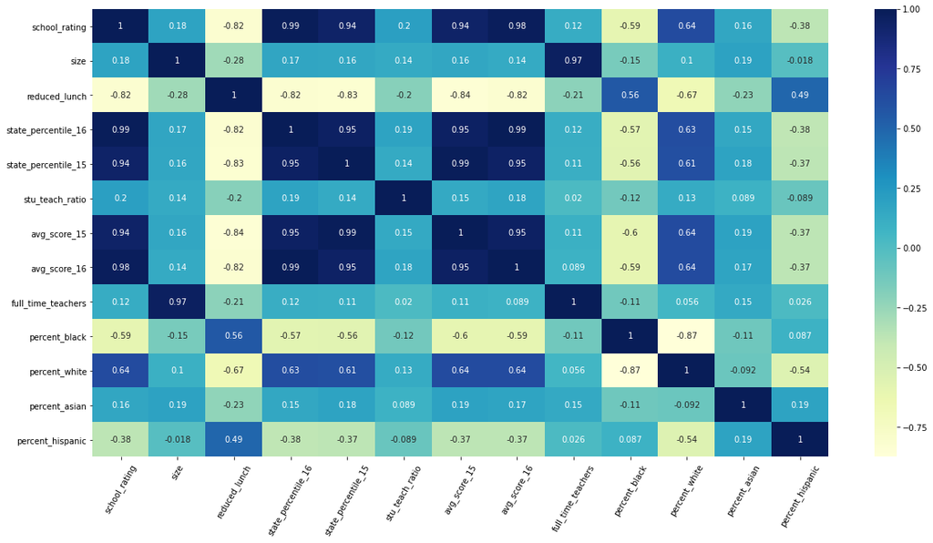

```python
import matplotlib.pyplot as plt
import seaborn as sns
import pandas as pd
%matplotlib inline

plt.figure(figsize=(20,10))

df = pd.read_csv(r"C:\Users\m2021\OneDrive\Documents\AI\Machine Learning\Demo_Datasets\Demo Datasets\Lesson 3\middle_tn_schools.csv")

correlations = df.corr()

ax = sns.heatmap(data = correlations, cmap='YlGnBu', annot=True)

plt.yticks(rotation=0)
plt.xticks(rotation=60)
plt.show()
```

```python
df.info()
```

```
<class 'pandas.core.frame.DataFrame'>
RangeIndex: 347 entries, 0 to 346
Data columns (total 15 columns):
 #   Column               Non-Null Count  Dtype
---  ------               --------------  -----
 0   name                 347 non-null    object
 1   school_rating        347 non-null    float64
 2   size                 347 non-null    float64
 3   reduced_lunch        347 non-null    float64
 4   state_percentile_16  347 non-null    float64
 5   state_percentile_15  341 non-null    float64
 6   stu_teach_ratio      347 non-null    float64
 7   school_type          347 non-null    object
 8   avg_score_15         341 non-null    float64
 9   avg_score_16         347 non-null    float64
 10  full_time_teachers   347 non-null    float64
 11  percent_black        347 non-null    float64
 12  percent_white        347 non-null    float64
 13  percent_asian        347 non-null    float64
 14  percent_hispanic     347 non-null    float64
dtypes: float64(13), object(2)
memory usage: 40.8+ KB
```

```python
quant_df = df.drop(['name', 'school_type'], axis=1)
```

```python
df.select_dtypes(['O']).info()
```

```
<class 'pandas.core.frame.DataFrame'>
RangeIndex: 347 entries, 0 to 346
Data columns (total 2 columns):
 #   Column       Non-Null Count  Dtype
---  ------       --------------  -----
 0   name         347 non-null    object
 1   school_type  347 non-null    object
dtypes: object(2)
memory usage: 5.5+ KB
```

```python
df.select_dtypes(['float']).info()
```

```
<class 'pandas.core.frame.DataFrame'>
RangeIndex: 347 entries, 0 to 346
Data columns (total 13 columns):
 #   Column               Non-Null Count  Dtype
---  ------               --------------  -----
 0   school_rating        347 non-null    float64
 1   size                 347 non-null    float64
 2   reduced_lunch        347 non-null    float64
 3   state_percentile_16  347 non-null    float64
 4   state_percentile_15  341 non-null    float64
 5   stu_teach_ratio      347 non-null    float64
 6   avg_score_15         341 non-null    float64
 7   avg_score_16         347 non-null    float64
 8   full_time_teachers   347 non-null    float64
 9   percent_black        347 non-null    float64
 10  percent_white        347 non-null    float64
 11  percent_asian        347 non-null    float64
 12  percent_hispanic     347 non-null    float64
dtypes: float64(13)
memory usage: 35.4 KB
```

```python
quant_df.info()
```

```
<class 'pandas.core.frame.DataFrame'>
RangeIndex: 347 entries, 0 to 346
Data columns (total 13 columns):
 #   Column               Non-Null Count  Dtype
---  ------               --------------  -----
 0   school_rating        347 non-null    float64
 1   size                 347 non-null    float64
 2   reduced_lunch        347 non-null    float64
 3   state_percentile_16  347 non-null    float64
 4   state_percentile_15  341 non-null    float64
 5   stu_teach_ratio      347 non-null    float64
 6   avg_score_15         341 non-null    float64
 7   avg_score_16         347 non-null    float64
 8   full_time_teachers   347 non-null    float64
 9   percent_black        347 non-null    float64
 10  percent_white        347 non-null    float64
 11  percent_asian        347 non-null    float64
 12  percent_hispanic     347 non-null    float64
dtypes: float64(13)
memory usage: 35.4 KB
```

```python
df
```

|  | name | school_rating | size | reduced_lunch | state_percentile_16 | state_percentile_15 | stu_teach_ratio | school_type | avg_score_15 | avg_score_16 | full_time_teachers | percent_black | percent_white | percent_asian | percent_hispanic |
| --- | --- | --- | --- | --- | --- | --- | --- | --- | --- | --- | --- | --- | --- | --- | --- |
| 0 | Allendale Elementary School | 5.0 | 851.0 | 10.0 | 90.2 | 95.8 | 15.7 | Public | 89.4 | 85.2 | 54.0 | 2.9 | 85.5 | 1.6 | 5.6 |
| 1 | Anderson Elementary | 2.0 | 412.0 | 71.0 | 32.8 | 37.3 | 12.8 | Public | 43.0 | 38.3 | 32.0 | 3.9 | 86.7 | 1.0 | 4.9 |
| 2 | Avoca Elementary | 4.0 | 482.0 | 43.0 | 78.4 | 83.6 | 16.6 | Public | 75.7 | 73.0 | 29.0 | 1.0 | 91.5 | 1.2 | 4.4 |
| 3 | Bailey Middle | 0.0 | 394.0 | 91.0 | 1.6 | 1.0 | 13.1 | Public Magnet | 2.1 | 4.4 | 30.0 | 80.7 | 11.7 | 2.3 | 4.3 |
| 4 | Barfield Elementary | 4.0 | 948.0 | 26.0 | 85.3 | 89.2 | 14.8 | Public | 81.3 | 79.6 | 64.0 | 11.8 | 71.2 | 7.1 | 6.0 |
| ... | ... | ... | ... | ... | ... | ... | ... | ... | ... | ... | ... | ... | ... | ... | ... |
| 342 | Winfree Bryant Middle School | 3.0 | 611.0 | 57.0 | 59.1 | 65.2 | 16.9 | Public | 61.4 | 57.7 | 36.0 | 15.2 | 66.3 | 1.5 | 15.7 |
| 343 | Winstead Elementary School | 5.0 | 515.0 | 8.0 | 93.9 | 97.0 | 14.3 | Public | 92.0 | 89.3 | 36.0 | 3.3 | 87.4 | 3.1 | 4.1 |
| 344 | Woodland Elementary | 4.0 | 424.0 | 55.0 | 84.8 | 76.7 | 14.1 | Public | 69.4 | 79.4 | 30.0 | 11.6 | 70.5 | 2.1 | 9.7 |
| 345 | Woodland Middle School | 5.0 | 866.0 | 2.0 | 93.3 | 97.1 | 19.2 | Public | 89.8 | 84.9 | 45.0 | 4.5 | 77.6 | 10.0 | 4.4 |
| 346 | Wright Middle | 0.0 | 829.0 | 89.0 | 4.5 | 1.2 | 16.5 | Public | 2.7 | 9.6 | 50.0 | 22.3 | 21.0 | 6.6 | 49.5 |

347 rows × 15 columns

```python
pivot = pd.pivot_table(df, index='school_type', values='school_rating', aggfunc=['mean',"count"])
```

```python
pivot
```

| school_type | mean school_rating | count school_rating |
| --- | --- | --- |
| Public | 3.092466 | 292 |
| Public Charter | 3.375000 | 8 |
| Public Magnet | 2.065217 | 46 |
| Public Virtual | 5.000000 | 1 |

```python
df.sort_values(by='school_rating', ascending=False)
```

|  | name | school_rating | size | reduced_lunch | state_percentile_16 | state_percentile_15 | stu_teach_ratio | school_type | avg_score_15 | avg_score_16 | full_time_teachers | percent_black | percent_white | percent_asian | percent_hispanic |
| --- | --- | --- | --- | --- | --- | --- | --- | --- | --- | --- | --- | --- | --- | --- | --- |
| 0 | Allendale Elementary School | 5.0 | 851.0 | 10.0 | 90.2 | 95.8 | 15.7 | Public | 89.4 | 85.2 | 54.0 | 2.9 | 85.5 | 1.6 | 5.6 |
| 95 | Granbery Elementary | 5.0 | 742.0 | 43.0 | 89.9 | 91.0 | 17.2 | Public | 83.6 | 84.8 | 43.0 | 16.6 | 59.7 | 9.7 | 11.6 |
| 123 | Hume - Fogg High | 5.0 | 915.0 | 29.0 | 98.6 | 97.0 | 19.8 | Public Magnet | 89.6 | 97.9 | 46.0 | 21.4 | 63.1 | 8.6 | 6.2 |
| 263 | Sango Elementary | 5.0 | 563.0 | 18.0 | 96.6 | 95.3 | 14.0 | Public | 89.0 | 93.0 | 40.0 | 6.4 | 76.9 | 2.1 | 8.5 |
| 264 | Scales Elementary | 5.0 | 785.0 | 2.0 | 98.4 | 97.6 | 16.7 | Public | 93.2 | 96.0 | 47.0 | 1.3 | 88.4 | 4.1 | 2.7 |
| ... | ... | ... | ... | ... | ... | ... | ... | ... | ... | ... | ... | ... | ... | ... | ... |
| 143 | John Early Middle | 0.0 | 482.0 | 86.0 | 3.4 | 2.5 | 12.6 | Public Magnet | 5.2 | 7.0 | 38.0 | 84.4 | 9.8 | 2.5 | 2.5 |
| 248 | Robert E. Lilliard Elementary | 0.0 | 400.0 | 92.0 | 6.7 | 11.1 | 14.8 | Public Magnet | 17.1 | 12.0 | 27.0 | 92.0 | 3.5 | 0.8 | 2.3 |
| 94 | Gra-Mar Middle | 0.0 | 406.0 | 90.0 | 2.4 | 3.7 | 15.0 | Public | 6.8 | 5.8 | 27.0 | 74.1 | 14.5 | 1.0 | 8.1 |
| 50 | Cumberland Elementary | 0.0 | 456.0 | 91.0 | 1.5 | 4.4 | 14.7 | Public | 8.8 | 4.8 | 31.0 | 79.6 | 8.8 | 0.2 | 8.6 |
| 346 | Wright Middle | 0.0 | 829.0 | 89.0 | 4.5 | 1.2 | 16.5 | Public | 2.7 | 9.6 | 50.0 | 22.3 | 21.0 | 6.6 | 49.5 |

347 rows × 15 columns

```python
sales = pd.read_csv(r'D:\Master Program\Machine Learning\files\files\data\Sales.csv')
```

```python
sales
```

|  | Date | Region | Sales Rep | Customer | Product | COGS | Sales |
| --- | --- | --- | --- | --- | --- | --- | --- |
| 0 | 6/7/2006 | MidWest | Jon | Nature Company | QDA Item | $5,395.13 | $9,809.32 |
| 1 | 5/18/2006 | MidWest | Chin | The Economist | PGQ Item | $8,649.28 | $9,250.57 |
| 2 | 5/6/2006 | MidWest | Luke | McLendon's Hardware | WAJ Item | $3,172.06 | $8,573.14 |
| 3 | 4/25/2006 | MidWest | Rhonda | ExcelIsVeryFun.com | WSQ Item | $8,333.41 | $8,912.74 |
| 4 | 4/3/2006 | MidWest | Luke | Costco | SLL Item | $8,792.47 | $9,991.44 |
| ... | ... | ... | ... | ... | ... | ... | ... |
| 1994 | 6/19/2004 | West | Steven | Google | QVQ Item | $1,517.28 | $2,231.30 |
| 1995 | 6/19/2004 | West | Luke | McLendon's Hardware | PRP Item | $121.98 | $271.06 |
| 1996 | 6/18/2004 | West | Steven | McLendon's Hardware | SQC Item | $3,852.53 | $8,561.17 |
| 1997 | 6/17/2004 | West | Jeri | Costco | XHX Item | $4,577.73 | $7,758.86 |
| 1998 | 6/17/2004 | West | Jon | Sherman Williams | UBU Item | $4,919.60 | $7,234.71 |

1999 rows × 7 columns

```python
pivot0=pd.pivot_table(sales, index="Customer", columns="Sales Rep", aggfunc="" )
```

[output not shown]

```python
sales['COGS'] = sales['COGS'].str.replace('[$,]','').astype(float)
```

```python
sales['Sales'] = sales['Sales'].str.replace('[$,]','').astype(float)
```

```python
sales
```

|  | Date | Region | Sales Rep | Customer | Product | COGS | Sales |
| --- | --- | --- | --- | --- | --- | --- | --- |
| 0 | 6/7/2006 | MidWest | Jon | Nature Company | QDA Item | 5395.13 | 9809.32 |
| 1 | 5/18/2006 | MidWest | Chin | The Economist | PGQ Item | 8649.28 | 9250.57 |
| 2 | 5/6/2006 | MidWest | Luke | McLendon's Hardware | WAJ Item | 3172.06 | 8573.14 |
| 3 | 4/25/2006 | MidWest | Rhonda | ExcelIsVeryFun.com | WSQ Item | 8333.41 | 8912.74 |
| 4 | 4/3/2006 | MidWest | Luke | Costco | SLL Item | 8792.47 | 9991.44 |
| ... | ... | ... | ... | ... | ... | ... | ... |
| 1994 | 6/19/2004 | West | Steven | Google | QVQ Item | 1517.28 | 2231.30 |
| 1995 | 6/19/2004 | West | Luke | McLendon's Hardware | PRP Item | 121.98 | 271.06 |
| 1996 | 6/18/2004 | West | Steven | McLendon's Hardware | SQC Item | 3852.53 | 8561.17 |
| 1997 | 6/17/2004 | West | Jeri | Costco | XHX Item | 4577.73 | 7758.86 |
| 1998 | 6/17/2004 | West | Jon | Sherman Williams | UBU Item | 4919.60 | 7234.71 |

1999 rows × 7 columns

```python
pd.pivot_table(sales, columns='Region', index='Sales Rep', values='Sales', aggfunc='mean')
```

| Region Sales Rep | MidWest | North | NorthEast | SouthEast | West |
| --- | --- | --- | --- | --- | --- |
| Chin | 5060.973265 | 5055.530392 | 5291.745870 | 5321.175625 | 4363.894324 |
| Jeri | 4603.660222 | 5476.923871 | 4820.842955 | 4503.661020 | 5192.327321 |
| Jon | 5794.474750 | 5503.677447 | 4524.255000 | 5234.038302 | 4690.801892 |
| Luke | 6036.709091 | 5133.875778 | 4909.052794 | 4957.148571 | 4668.821778 |
| Rhonda | 4821.384500 | 5035.068710 | 5026.004875 | 4915.795000 | 5293.770000 |
| Sheliadawn | 5299.012000 | 4714.169722 | 5475.471474 | 4614.007353 | 5100.272703 |
| Steven | 4881.611176 | 5121.228696 | 4863.301845 | 5683.269167 | 5561.415882 |
| Troung | 5817.452368 | 4744.384167 | 4814.023409 | 5067.615652 | 4376.980769 |

```python
quant_df.describe()
```

|  | school_rating | size | reduced_lunch | state_percentile_16 | state_percentile_15 | stu_teach_ratio | avg_score_15 | avg_score_16 | full_time_teachers | percent_black | percent_white | percent_asian | percent_hispanic |
| --- | --- | --- | --- | --- | --- | --- | --- | --- | --- | --- | --- | --- | --- |
| count | 347.000000 | 347.000000 | 347.000000 | 347.000000 | 341.000000 | 347.000000 | 341.000000 | 347.000000 | 347.000000 | 347.000000 | 347.000000 | 347.000000 | 347.000000 |
| mean | 2.968300 | 699.472622 | 50.279539 | 58.801729 | 58.249267 | 15.461671 | 57.004692 | 57.049856 | 44.939481 | 21.197983 | 61.673487 | 2.642651 | 11.164553 |
| std | 1.690377 | 400.598636 | 25.480236 | 32.540747 | 32.702630 | 5.725170 | 26.696450 | 27.968974 | 22.053386 | 23.562538 | 27.274859 | 3.109629 | 12.030608 |
| min | 0.000000 | 53.000000 | 2.000000 | 0.200000 | 0.600000 | 4.700000 | 1.500000 | 0.100000 | 2.000000 | 0.000000 | 1.100000 | 0.000000 | 0.000000 |
| 25% | 2.000000 | 420.500000 | 30.000000 | 30.950000 | 27.100000 | 13.700000 | 37.600000 | 37.000000 | 30.000000 | 3.600000 | 40.600000 | 0.750000 | 3.800000 |
| 50% | 3.000000 | 595.000000 | 51.000000 | 66.400000 | 65.800000 | 15.000000 | 61.800000 | 60.700000 | 40.000000 | 13.500000 | 68.700000 | 1.600000 | 6.400000 |
| 75% | 4.000000 | 851.000000 | 71.500000 | 88.000000 | 88.600000 | 16.700000 | 79.600000 | 80.250000 | 54.000000 | 28.350000 | 85.950000 | 3.100000 | 13.800000 |
| max | 5.000000 | 2314.000000 | 98.000000 | 99.800000 | 99.800000 | 111.000000 | 99.000000 | 98.900000 | 140.000000 | 97.400000 | 99.700000 | 21.100000 | 65.200000 |

```python
df.select_dtypes('O').describe()
```

|  | name | school_type |
| --- | --- | --- |
| count | 347 | 347 |
| unique | 341 | 4 |
| top | Liberty Elementary | Public |
| freq | 3 | 292 |

```python
df.describe()
```

|  | school_rating | size | reduced_lunch | state_percentile_16 | state_percentile_15 | stu_teach_ratio | avg_score_15 | avg_score_16 | full_time_teachers | percent_black | percent_white | percent_asian | percent_hispanic |
| --- | --- | --- | --- | --- | --- | --- | --- | --- | --- | --- | --- | --- | --- |
| count | 347.000000 | 347.000000 | 347.000000 | 347.000000 | 341.000000 | 347.000000 | 341.000000 | 347.000000 | 347.000000 | 347.000000 | 347.000000 | 347.000000 | 347.000000 |
| mean | 2.968300 | 699.472622 | 50.279539 | 58.801729 | 58.249267 | 15.461671 | 57.004692 | 57.049856 | 44.939481 | 21.197983 | 61.673487 | 2.642651 | 11.164553 |
| std | 1.690377 | 400.598636 | 25.480236 | 32.540747 | 32.702630 | 5.725170 | 26.696450 | 27.968974 | 22.053386 | 23.562538 | 27.274859 | 3.109629 | 12.030608 |
| min | 0.000000 | 53.000000 | 2.000000 | 0.200000 | 0.600000 | 4.700000 | 1.500000 | 0.100000 | 2.000000 | 0.000000 | 1.100000 | 0.000000 | 0.000000 |
| 25% | 2.000000 | 420.500000 | 30.000000 | 30.950000 | 27.100000 | 13.700000 | 37.600000 | 37.000000 | 30.000000 | 3.600000 | 40.600000 | 0.750000 | 3.800000 |
| 50% | 3.000000 | 595.000000 | 51.000000 | 66.400000 | 65.800000 | 15.000000 | 61.800000 | 60.700000 | 40.000000 | 13.500000 | 68.700000 | 1.600000 | 6.400000 |
| 75% | 4.000000 | 851.000000 | 71.500000 | 88.000000 | 88.600000 | 16.700000 | 79.600000 | 80.250000 | 54.000000 | 28.350000 | 85.950000 | 3.100000 | 13.800000 |
| max | 5.000000 | 2314.000000 | 98.000000 | 99.800000 | 99.800000 | 111.000000 | 99.000000 | 98.900000 | 140.000000 | 97.400000 | 99.700000 | 21.100000 | 65.200000 |

```python
quant_df.describe().unstack()
```

```
school_rating     count    347.000000
                  mean       2.968300
                  std        1.690377
                  min        0.000000
                  25%        2.000000
                              ...
percent_hispanic  min        0.000000
                  25%        3.800000
                  50%        6.400000
                  75%       13.800000
                  max       65.200000
Length: 104, dtype: float64
```

```python
quant_df.mean()
```

```
school_rating            2.968300
size                   699.472622
reduced_lunch           50.279539
state_percentile_16     58.801729
state_percentile_15     58.249267
stu_teach_ratio         15.461671
avg_score_15            57.004692
avg_score_16            57.049856
full_time_teachers      44.939481
percent_black           21.197983
percent_white           61.673487
percent_asian            2.642651
percent_hispanic        11.164553
dtype: float64
```

```python
quant_df.mean(axis=1)
```

```
0      107.069231
1       59.823077
2       75.646154
3       48.938462
4      114.484615
          ...
342     82.000000
343     80.646154
344     71.638462
345    107.600000
346     84.761538
Length: 347, dtype: float64
```

```python
quant_df.var()
```

```
school_rating               2.857374
size                   160479.267312
reduced_lunch             649.242441
state_percentile_16      1058.900228
state_percentile_15      1069.461977
stu_teach_ratio            32.777573
avg_score_15              712.700449
avg_score_16              782.263490
full_time_teachers        486.351818
percent_black             555.193204
percent_white             743.917908
percent_asian               9.669794
percent_hispanic          144.735532
dtype: float64
```

```python
quant_df.sum()
```

```
school_rating            1030.0
size                   242717.0
reduced_lunch           17447.0
state_percentile_16     20404.2
state_percentile_15     19863.0
stu_teach_ratio          5365.2
avg_score_15            19438.6
avg_score_16            19796.3
full_time_teachers      15594.0
percent_black            7355.7
percent_white           21400.7
percent_asian             917.0
percent_hispanic         3874.1
dtype: float64
```

```python
quant_df.std()
```

```
school_rating            1.690377
size                   400.598636
reduced_lunch           25.480236
state_percentile_16     32.540747
state_percentile_15     32.702630
stu_teach_ratio          5.725170
avg_score_15            26.696450
avg_score_16            27.968974
full_time_teachers      22.053386
percent_black           23.562538
percent_white           27.274859
percent_asian            3.109629
percent_hispanic        12.030608
dtype: float64
```

```python
quant_df.count()
```

```
school_rating          347
size                   347
reduced_lunch          347
state_percentile_16    347
state_percentile_15    341
stu_teach_ratio        347
avg_score_15           341
avg_score_16           347
full_time_teachers     347
percent_black          347
percent_white          347
percent_asian          347
percent_hispanic       347
dtype: int64
```

```python
quant_df.aggregate(['sum', 'mean'])
```

|  | school_rating | size | reduced_lunch | state_percentile_16 | state_percentile_15 | stu_teach_ratio | avg_score_15 | avg_score_16 | full_time_teachers | percent_black | percent_white | percent_asian | percent_hispanic |
| --- | --- | --- | --- | --- | --- | --- | --- | --- | --- | --- | --- | --- | --- |
| sum | 1030.0000 | 242717.000000 | 17447.000000 | 20404.200000 | 19863.000000 | 5365.200000 | 19438.600000 | 19796.300000 | 15594.000000 | 7355.700000 | 21400.700000 | 917.000000 | 3874.100000 |
| mean | 2.9683 | 699.472622 | 50.279539 | 58.801729 | 58.249267 | 15.461671 | 57.004692 | 57.049856 | 44.939481 | 21.197983 | 61.673487 | 2.642651 | 11.164553 |

```python
quant_df.aggregate(['min', 'max', 'var','std'])
```

|  | school_rating | size | reduced_lunch | state_percentile_16 | state_percentile_15 | stu_teach_ratio | avg_score_15 | avg_score_16 | full_time_teachers | percent_black | percent_white | percent_asian | percent_hispanic |
| --- | --- | --- | --- | --- | --- | --- | --- | --- | --- | --- | --- | --- | --- |
| min | 0.000000 | 53.000000 | 2.000000 | 0.200000 | 0.600000 | 4.700000 | 1.500000 | 0.100000 | 2.000000 | 0.000000 | 1.100000 | 0.000000 | 0.000000 |
| max | 5.000000 | 2314.000000 | 98.000000 | 99.800000 | 99.800000 | 111.000000 | 99.000000 | 98.900000 | 140.000000 | 97.400000 | 99.700000 | 21.100000 | 65.200000 |
| var | 2.857374 | 160479.267312 | 649.242441 | 1058.900228 | 1069.461977 | 32.777573 | 712.700449 | 782.263490 | 486.351818 | 555.193204 | 743.917908 | 9.669794 | 144.735532 |
| std | 1.690377 | 400.598636 | 25.480236 | 32.540747 | 32.702630 | 5.725170 | 26.696450 | 27.968974 | 22.053386 | 23.562538 | 27.274859 | 3.109629 | 12.030608 |

```python
import pandas as pd
world_cup={'Team':['West Indies','West Indies','India','Australia','Pakistan','Sri Lanka',
                   'Australia','Australia','Australia','India','Australia','England'],
           'Rank':[7,7,2,1,6,4,1,1,1,2,1,3],
           'Year':[1975,1979,1983,1987,1992,1996,1999,2003,2007,2011,2015,2019]}
```

```python
df = pd.DataFrame(world_cup)
```

```python
df
```

|  | Team | Rank | Year |
| --- | --- | --- | --- |
| 0 | West Indies | 7 | 1975 |
| 1 | West Indies | 7 | 1979 |
| 2 | India | 2 | 1983 |
| 3 | Australia | 1 | 1987 |
| 4 | Pakistan | 6 | 1992 |
| 5 | Sri Lanka | 4 | 1996 |
| 6 | Australia | 1 | 1999 |
| 7 | Australia | 1 | 2003 |
| 8 | Australia | 1 | 2007 |
| 9 | India | 2 | 2011 |
| 10 | Australia | 1 | 2015 |
| 11 | England | 3 | 2019 |

```python
df.groupby(["Team","Rank"]).groups
```

```
{('Australia', 1): [3, 6, 7, 8, 10], ('England', 3): [11], ('India', 2): [2, 9], ('Pakistan', 6): [4], ('Sri Lanka', 4): [5], ('West Indies', 7): [0, 1]}
```

```python
df.groupby(['Team']).count()
```

| Team | Rank | Year |
| --- | --- | --- |
| Australia | 5 | 5 |
| England | 1 | 1 |
| India | 2 | 2 |
| Pakistan | 1 | 1 |
| Sri Lanka | 1 | 1 |
| West Indies | 2 | 2 |

```python
df = pd.read_csv(r"C:\Users\m2021\OneDrive\Documents\AI\Machine Learning\Demo_Datasets\Demo Datasets\Lesson 3\middle_tn_schools.csv")
```

```python
df
```

|  | name | school_rating | size | reduced_lunch | state_percentile_16 | state_percentile_15 | stu_teach_ratio | school_type | avg_score_15 | avg_score_16 | full_time_teachers | percent_black | percent_white | percent_asian | percent_hispanic |
| --- | --- | --- | --- | --- | --- | --- | --- | --- | --- | --- | --- | --- | --- | --- | --- |
| 0 | Allendale Elementary School | 5.0 | 851.0 | 10.0 | 90.2 | 95.8 | 15.7 | Public | 89.4 | 85.2 | 54.0 | 2.9 | 85.5 | 1.6 | 5.6 |
| 1 | Anderson Elementary | 2.0 | 412.0 | 71.0 | 32.8 | 37.3 | 12.8 | Public | 43.0 | 38.3 | 32.0 | 3.9 | 86.7 | 1.0 | 4.9 |
| 2 | Avoca Elementary | 4.0 | 482.0 | 43.0 | 78.4 | 83.6 | 16.6 | Public | 75.7 | 73.0 | 29.0 | 1.0 | 91.5 | 1.2 | 4.4 |
| 3 | Bailey Middle | 0.0 | 394.0 | 91.0 | 1.6 | 1.0 | 13.1 | Public Magnet | 2.1 | 4.4 | 30.0 | 80.7 | 11.7 | 2.3 | 4.3 |
| 4 | Barfield Elementary | 4.0 | 948.0 | 26.0 | 85.3 | 89.2 | 14.8 | Public | 81.3 | 79.6 | 64.0 | 11.8 | 71.2 | 7.1 | 6.0 |
| ... | ... | ... | ... | ... | ... | ... | ... | ... | ... | ... | ... | ... | ... | ... | ... |
| 342 | Winfree Bryant Middle School | 3.0 | 611.0 | 57.0 | 59.1 | 65.2 | 16.9 | Public | 61.4 | 57.7 | 36.0 | 15.2 | 66.3 | 1.5 | 15.7 |
| 343 | Winstead Elementary School | 5.0 | 515.0 | 8.0 | 93.9 | 97.0 | 14.3 | Public | 92.0 | 89.3 | 36.0 | 3.3 | 87.4 | 3.1 | 4.1 |
| 344 | Woodland Elementary | 4.0 | 424.0 | 55.0 | 84.8 | 76.7 | 14.1 | Public | 69.4 | 79.4 | 30.0 | 11.6 | 70.5 | 2.1 | 9.7 |
| 345 | Woodland Middle School | 5.0 | 866.0 | 2.0 | 93.3 | 97.1 | 19.2 | Public | 89.8 | 84.9 | 45.0 | 4.5 | 77.6 | 10.0 | 4.4 |
| 346 | Wright Middle | 0.0 | 829.0 | 89.0 | 4.5 | 1.2 | 16.5 | Public | 2.7 | 9.6 | 50.0 | 22.3 | 21.0 | 6.6 | 49.5 |

347 rows × 15 columns

```python
df.groupby('school_type').mean()['school_rating']
```

```
school_type
Public            3.092466
Public Charter    3.375000
Public Magnet     2.065217
Public Virtual    5.000000
Name: school_rating, dtype: float64
```

```python
grouped_mean = df.groupby('school_type').mean()['school_rating']
```

```python
type(grouped_mean)
```

```
pandas.core.series.Series
```

```python
grouped_mean
```

```
school_type
Public            3.092466
Public Charter    3.375000
Public Magnet     2.065217
Public Virtual    5.000000
Name: school_rating, dtype: float64
```

```python
grouped_mean.reset_index()
```

|  | school_type | school_rating |
| --- | --- | --- |
| 0 | Public | 3.092466 |
| 1 | Public Charter | 3.375000 |
| 2 | Public Magnet | 2.065217 |
| 3 | Public Virtual | 5.000000 |

```python
grouped_mean.reset_index(drop=True)
```

```
0    3.092466
1    3.375000
2    2.065217
3    5.000000
Name: school_rating, dtype: float64
```

```python
grouped_mean
```

```
school_type
Public            3.092466
Public Charter    3.375000
Public Magnet     2.065217
Public Virtual    5.000000
Name: school_rating, dtype: float64
```

```python
import pandas as pd

one = pd.DataFrame({
   'Name': ['Alex', 'Amy', 'Allen', 'Alice', 'Ayoung'],
   'subject_id':['sub1','sub2','sub4','sub6','sub5'],
   'Marks_scored':[98,90,87,69,78]},
   index=[1,2,3,4,6])

two = pd.DataFrame({
   'Name_two': ['Billy', 'Brian', 'Bran', 'Bryce', 'Betty'],
   'subject_id':['sub2','sub4','sub3','sub6','sub5'],
   'Marks_scored':[89,80,79,97,88]},
   index=[1,2,3,4,5])
```

```python
one
```

|  | Name | subject_id | Marks_scored |
| --- | --- | --- | --- |
| 1 | Alex | sub1 | 98 |
| 2 | Amy | sub2 | 90 |
| 3 | Allen | sub4 | 87 |
| 4 | Alice | sub6 | 69 |
| 6 | Ayoung | sub5 | 78 |

```python
two
```

|  | Name_two | subject_id | Marks_scored |
| --- | --- | --- | --- |
| 1 | Billy | sub2 | 89 |
| 2 | Brian | sub4 | 80 |
| 3 | Bran | sub3 | 79 |
| 4 | Bryce | sub6 | 97 |
| 5 | Betty | sub5 | 88 |

```python
pd.concat([one,two],axis=0)
```

|  | Name | subject_id | Marks_scored | Name_two |
| --- | --- | --- | --- | --- |
| 1 | Alex | sub1 | 98 | NaN |
| 2 | Amy | sub2 | 90 | NaN |
| 3 | Allen | sub4 | 87 | NaN |
| 4 | Alice | sub6 | 69 | NaN |
| 6 | Ayoung | sub5 | 78 | NaN |
| 1 | NaN | sub2 | 89 | Billy |
| 2 | NaN | sub4 | 80 | Brian |
| 3 | NaN | sub3 | 79 | Bran |
| 4 | NaN | sub6 | 97 | Bryce |
| 5 | NaN | sub5 | 88 | Betty |

```python
one
```

|  | Name | subject_id | Marks_scored |
| --- | --- | --- | --- |
| 1 | Alex | sub1 | 98 |
| 2 | Amy | sub2 | 90 |
| 3 | Allen | sub4 | 87 |
| 4 | Alice | sub6 | 69 |
| 6 | Ayoung | sub5 | 78 |

```python
two
```

|  | Name_two | subject_id | Marks_scored |
| --- | --- | --- | --- |
| 1 | Billy | sub2 | 89 |
| 2 | Brian | sub4 | 80 |
| 3 | Bran | sub3 | 79 |
| 4 | Bryce | sub6 | 97 |
| 5 | Betty | sub5 | 88 |

```python
pd.concat([one,two],axis=1)
```

|  | Name | subject_id | Marks_scored | Name_two | subject_id | Marks_scored |
| --- | --- | --- | --- | --- | --- | --- |
| 1 | Alex | sub1 | 98.0 | Billy | sub2 | 89.0 |
| 2 | Amy | sub2 | 90.0 | Brian | sub4 | 80.0 |
| 3 | Allen | sub4 | 87.0 | Bran | sub3 | 79.0 |
| 4 | Alice | sub6 | 69.0 | Bryce | sub6 | 97.0 |
| 5 | NaN | NaN | NaN | Betty | sub5 | 88.0 |
| 6 | Ayoung | sub5 | 78.0 | NaN | NaN | NaN |

```python
import pandas as pd

one = pd.DataFrame({
   'Name': ['Alex', 'Amy', 'Allen', 'Alice', 'Ayoung'],
   'subject_id':['sub1','sub2','sub4','sub6','sub5'],
   'Marks_scored':[98,90,87,69,78]},
   index=[1,2,3,4,6])

two = pd.DataFrame({
   'Name': ['Billy', 'Brian', 'Bran', 'Bryce', 'Betty'],
   'subject_id':['sub2','sub4','sub3','sub6','sub5'],
   'Marks_scored':[89,80,79,97,88]},
   index=[1,2,3,4,5])
```

```python
one
```

|  | Name | subject_id | Marks_scored |
| --- | --- | --- | --- |
| 1 | Alex | sub1 | 98 |
| 2 | Amy | sub2 | 90 |
| 3 | Allen | sub4 | 87 |
| 4 | Alice | sub6 | 69 |
| 6 | Ayoung | sub5 | 78 |

```python
one.index = one['Name']
```

```python
one
```

| Name | Name | subject_id | Marks_scored |
| --- | --- | --- | --- |
| Alex | Alex | sub1 | 98 |
| Amy | Amy | sub2 | 90 |
| Allen | Allen | sub4 | 87 |
| Alice | Alice | sub6 | 69 |
| Ayoung | Ayoung | sub5 | 78 |

```python
two
```

|  | Name | subject_id | Marks_scored |
| --- | --- | --- | --- |
| 1 | Billy | sub2 | 89 |
| 2 | Brian | sub4 | 80 |
| 3 | Bran | sub3 | 79 |
| 4 | Bryce | sub6 | 97 |
| 5 | Betty | sub5 | 88 |

```python
two.index = two['Name']
```

```python
two
```

| Name | Name | subject_id | Marks_scored |
| --- | --- | --- | --- |
| Billy | Billy | sub2 | 89 |
| Brian | Brian | sub4 | 80 |
| Bran | Bran | sub3 | 79 |
| Bryce | Bryce | sub6 | 97 |
| Betty | Betty | sub5 | 88 |

```python
data = pd.concat([one,two],axis=0)
```

```python
data
```

| Name | Name | subject_id | Marks_scored |
| --- | --- | --- | --- |
| Alex | Alex | sub1 | 98 |
| Amy | Amy | sub2 | 90 |
| Allen | Allen | sub4 | 87 |
| Alice | Alice | sub6 | 69 |
| Ayoung | Ayoung | sub5 | 78 |
| Billy | Billy | sub2 | 89 |
| Brian | Brian | sub4 | 80 |
| Bran | Bran | sub3 | 79 |
| Bryce | Bryce | sub6 | 97 |
| Betty | Betty | sub5 | 88 |

```python
data.iloc[[1,2],:]
```

| Name | Name | subject_id | Marks_scored |
| --- | --- | --- | --- |
| Amy | Amy | sub2 | 90 |
| Allen | Allen | sub4 | 87 |

```python
pd.concat([one,two],axis=1,join='outer')
```

| Name | Name | subject_id | Marks_scored | Name | subject_id | Marks_scored |
| --- | --- | --- | --- | --- | --- | --- |
| Alex | Alex | sub1 | 98.0 | NaN | NaN | NaN |
| Amy | Amy | sub2 | 90.0 | NaN | NaN | NaN |
| Allen | Allen | sub4 | 87.0 | NaN | NaN | NaN |
| Alice | Alice | sub6 | 69.0 | NaN | NaN | NaN |
| Ayoung | Ayoung | sub5 | 78.0 | NaN | NaN | NaN |
| Billy | NaN | NaN | NaN | Billy | sub2 | 89.0 |
| Brian | NaN | NaN | NaN | Brian | sub4 | 80.0 |
| Bran | NaN | NaN | NaN | Bran | sub3 | 79.0 |
| Bryce | NaN | NaN | NaN | Bryce | sub6 | 97.0 |
| Betty | NaN | NaN | NaN | Betty | sub5 | 88.0 |

```python
one = pd.DataFrame({
   'Name': ['Alex', 'Amy', 'Allen', 'Alice', 'Ayoung'],
   'subject_id':['sub1','sub2','sub4','sub6','sub5'],
   'Marks_scored':[98,90,87,69,78]},
   index=[1,2,3,4,6])

two = pd.DataFrame({
   'Name': ['Billy', 'Brian', 'Bran', 'Bryce', 'Betty'],
   'subject_id':['sub2','sub4','sub3','sub6','sub5'],
   'Marks_scored':[89,80,79,97,88]},
   index=[1,2,3,4,5])
```

```python
one
```

|  | Name | subject_id | Marks_scored |
| --- | --- | --- | --- |
| 1 | Alex | sub1 | 98 |
| 2 | Amy | sub2 | 90 |
| 3 | Allen | sub4 | 87 |
| 4 | Alice | sub6 | 69 |
| 6 | Ayoung | sub5 | 78 |

```python
two
```

|  | Name | subject_id | Marks_scored |
| --- | --- | --- | --- |
| 1 | Billy | sub2 | 89 |
| 2 | Brian | sub4 | 80 |
| 3 | Bran | sub3 | 79 |
| 4 | Bryce | sub6 | 97 |
| 5 | Betty | sub5 | 88 |

- left : LEFT OUTER JOIN : Use keys from left frame only
- right : RIGHT OUTER JOIN : Use keys from right frame only
- outer : FULL OUTER JOIN : Use union of keys from both frames
- inner : INNER JOIN : Use intersection of keys from both frames : default

```python
data = pd.merge(one,two,how='left',on='subject_id', suffixes=('_sec_A','_sec_B'))
data
```

|  | Name_sec_A | subject_id | Marks_scored_sec_A | Name_sec_B | Marks_scored_sec_B |
| --- | --- | --- | --- | --- | --- |
| 0 | Alex | sub1 | 98 | NaN | NaN |
| 1 | Amy | sub2 | 90 | Billy | 89.0 |
| 2 | Allen | sub4 | 87 | Brian | 80.0 |
| 3 | Alice | sub6 | 69 | Bryce | 97.0 |
| 4 | Ayoung | sub5 | 78 | Betty | 88.0 |

```python
one = pd.DataFrame({
   'Name': ['Alex', 'Amy', 'Allen', 'Alice', 'Ayoung'],
   'subject_id_1':['sub1','sub2','sub4','sub6','sub5'],
   'Marks_scored':[98,90,87,69,78]},
   index=[1,2,3,4,6])

two = pd.DataFrame({
   'Name': ['Billy', 'Brian', 'Bran', 'Bryce', 'Betty'],
   'subject_id_2':['sub2','sub4','sub3','sub6','sub5'],
   'Marks_scored':[89,80,79,97,88]},
   index=[1,2,3,4,5])
```

```python
one
```

|  | Name | subject_id_1 | Marks_scored |
| --- | --- | --- | --- |
| 1 | Alex | sub1 | 98 |
| 2 | Amy | sub2 | 90 |
| 3 | Allen | sub4 | 87 |
| 4 | Alice | sub6 | 69 |
| 6 | Ayoung | sub5 | 78 |

```python
two
```

|  | Name | subject_id_2 | Marks_scored |
| --- | --- | --- | --- |
| 1 | Billy | sub2 | 89 |
| 2 | Brian | sub4 | 80 |
| 3 | Bran | sub3 | 79 |
| 4 | Bryce | sub6 | 97 |
| 5 | Betty | sub5 | 88 |

```python
pd.merge(one,two,how='inner',left_on='subject_id_1', right_on='subject_id_2')
```

|  | Name_x | subject_id_1 | Marks_scored_x | Name_y | subject_id_2 | Marks_scored_y |
| --- | --- | --- | --- | --- | --- | --- |
| 0 | Amy | sub2 | 90 | Billy | sub2 | 89 |
| 1 | Allen | sub4 | 87 | Brian | sub4 | 80 |
| 2 | Alice | sub6 | 69 | Bryce | sub6 | 97 |
| 3 | Ayoung | sub5 | 78 | Betty | sub5 | 88 |

```python
one = pd.DataFrame({
   'Name': ['Alex', 'Amy', 'Allen', 'Alice', 'Ayoung'],
   'subject_id':['sub1','sub2','sub4','sub6','sub5'],
   'Marks_scored':[98,90,87,69,78]},
   index=[1,2,3,4,6])

two = pd.DataFrame({
   'Name': ['Billy', 'Brian', 'Bran', 'Bryce', 'Betty'],
   'subject_id':['sub2','sub4','sub3','sub6','sub5'],
   'Marks_scored':[89,80,79,97,88]},
   index=[1,2,3,4,5])
```

```python
one
```

|  | Name | subject_id | Marks_scored |
| --- | --- | --- | --- |
| 1 | Alex | sub1 | 98 |
| 2 | Amy | sub2 | 90 |
| 3 | Allen | sub4 | 87 |
| 4 | Alice | sub6 | 69 |
| 6 | Ayoung | sub5 | 78 |

```python
two
```

|  | Name | subject_id | Marks_scored |
| --- | --- | --- | --- |
| 1 | Billy | sub2 | 89 |
| 2 | Brian | sub4 | 80 |
| 3 | Bran | sub3 | 79 |
| 4 | Bryce | sub6 | 97 |
| 5 | Betty | sub5 | 88 |

```python
pd.merge(one,two,how='left',on='subject_id')
```

|  | Name_x | subject_id | Marks_scored_x | Name_y | Marks_scored_y |
| --- | --- | --- | --- | --- | --- |
| 0 | Alex | sub1 | 98 | NaN | NaN |
| 1 | Amy | sub2 | 90 | Billy | 89.0 |
| 2 | Allen | sub4 | 87 | Brian | 80.0 |
| 3 | Alice | sub6 | 69 | Bryce | 97.0 |
| 4 | Ayoung | sub5 | 78 | Betty | 88.0 |

```python
pd.merge(one,two,how='right',on='subject_id')
```

|  | Name_x | subject_id | Marks_scored_x | Name_y | Marks_scored_y |
| --- | --- | --- | --- | --- | --- |
| 0 | Amy | sub2 | 90.0 | Billy | 89 |
| 1 | Allen | sub4 | 87.0 | Brian | 80 |
| 2 | NaN | sub3 | NaN | Bran | 79 |
| 3 | Alice | sub6 | 69.0 | Bryce | 97 |
| 4 | Ayoung | sub5 | 78.0 | Betty | 88 |

```python
import pandas as pd
```

```python
df = pd.read_csv(r'C:\Users\m2021\OneDrive\Documents\AI\Machine Learning\Demo_Datasets\Demo Datasets\Lesson 3\middle_tn_schools.csv')
```

```python
df
```

|  | name | school_rating | size | reduced_lunch | state_percentile_16 | state_percentile_15 | stu_teach_ratio | school_type | avg_score_15 | avg_score_16 | full_time_teachers | percent_black | percent_white | percent_asian | percent_hispanic |
| --- | --- | --- | --- | --- | --- | --- | --- | --- | --- | --- | --- | --- | --- | --- | --- |
| 0 | Allendale Elementary School | 5.0 | 851.0 | 10.0 | 90.2 | 95.8 | 15.7 | Public | 89.4 | 85.2 | 54.0 | 2.9 | 85.5 | 1.6 | 5.6 |
| 1 | Anderson Elementary | 2.0 | 412.0 | 71.0 | 32.8 | 37.3 | 12.8 | Public | 43.0 | 38.3 | 32.0 | 3.9 | 86.7 | 1.0 | 4.9 |
| 2 | Avoca Elementary | 4.0 | 482.0 | 43.0 | 78.4 | 83.6 | 16.6 | Public | 75.7 | 73.0 | 29.0 | 1.0 | 91.5 | 1.2 | 4.4 |
| 3 | Bailey Middle | 0.0 | 394.0 | 91.0 | 1.6 | 1.0 | 13.1 | Public Magnet | 2.1 | 4.4 | 30.0 | 80.7 | 11.7 | 2.3 | 4.3 |
| 4 | Barfield Elementary | 4.0 | 948.0 | 26.0 | 85.3 | 89.2 | 14.8 | Public | 81.3 | 79.6 | 64.0 | 11.8 | 71.2 | 7.1 | 6.0 |
| ... | ... | ... | ... | ... | ... | ... | ... | ... | ... | ... | ... | ... | ... | ... | ... |
| 342 | Winfree Bryant Middle School | 3.0 | 611.0 | 57.0 | 59.1 | 65.2 | 16.9 | Public | 61.4 | 57.7 | 36.0 | 15.2 | 66.3 | 1.5 | 15.7 |
| 343 | Winstead Elementary School | 5.0 | 515.0 | 8.0 | 93.9 | 97.0 | 14.3 | Public | 92.0 | 89.3 | 36.0 | 3.3 | 87.4 | 3.1 | 4.1 |
| 344 | Woodland Elementary | 4.0 | 424.0 | 55.0 | 84.8 | 76.7 | 14.1 | Public | 69.4 | 79.4 | 30.0 | 11.6 | 70.5 | 2.1 | 9.7 |
| 345 | Woodland Middle School | 5.0 | 866.0 | 2.0 | 93.3 | 97.1 | 19.2 | Public | 89.8 | 84.9 | 45.0 | 4.5 | 77.6 | 10.0 | 4.4 |
| 346 | Wright Middle | 0.0 | 829.0 | 89.0 | 4.5 | 1.2 | 16.5 | Public | 2.7 | 9.6 | 50.0 | 22.3 | 21.0 | 6.6 | 49.5 |

347 rows × 15 columns

```python
df.isnull().sum()
```

```
name                   0
school_rating          0
size                   0
reduced_lunch          0
state_percentile_16    0
state_percentile_15    6
stu_teach_ratio        0
school_type            0
avg_score_15           6
avg_score_16           0
full_time_teachers     0
percent_black          0
percent_white          0
percent_asian          0
percent_hispanic       0
dtype: int64
```

```python
sr = df.isnull().mean()*100
```

```python
sr
```

```
name                   0.000000
school_rating          0.000000
size                   0.000000
reduced_lunch          0.000000
state_percentile_16    0.000000
state_percentile_15    1.729107
stu_teach_ratio        0.000000
school_type            0.000000
avg_score_15           1.729107
avg_score_16           0.000000
full_time_teachers     0.000000
percent_black          0.000000
percent_white          0.000000
percent_asian          0.000000
percent_hispanic       0.000000
dtype: float64
```

```python
sr[sr != 0]
```

```
state_percentile_15    1.729107
avg_score_15           1.729107
dtype: float64
```

```python
sr[sr>0].index
```

```
Index(['state_percentile_15', 'avg_score_15'], dtype='object')
```

```python
list(sr[sr>30].index)
```

```
[]
```

```python
df1 = df.copy()
```

```python
df1.drop(list(sr[sr>30].index), axis=1)
```

|  | name | school_rating | size | reduced_lunch | state_percentile_16 | state_percentile_15 | stu_teach_ratio | school_type | avg_score_15 | avg_score_16 | full_time_teachers | percent_black | percent_white | percent_asian | percent_hispanic |
| --- | --- | --- | --- | --- | --- | --- | --- | --- | --- | --- | --- | --- | --- | --- | --- |
| 0 | Allendale Elementary School | 5.0 | 851.0 | 10.0 | 90.2 | 95.8 | 15.7 | Public | 89.4 | 85.2 | 54.0 | 2.9 | 85.5 | 1.6 | 5.6 |
| 1 | Anderson Elementary | 2.0 | 412.0 | 71.0 | 32.8 | 37.3 | 12.8 | Public | 43.0 | 38.3 | 32.0 | 3.9 | 86.7 | 1.0 | 4.9 |
| 2 | Avoca Elementary | 4.0 | 482.0 | 43.0 | 78.4 | 83.6 | 16.6 | Public | 75.7 | 73.0 | 29.0 | 1.0 | 91.5 | 1.2 | 4.4 |
| 3 | Bailey Middle | 0.0 | 394.0 | 91.0 | 1.6 | 1.0 | 13.1 | Public Magnet | 2.1 | 4.4 | 30.0 | 80.7 | 11.7 | 2.3 | 4.3 |
| 4 | Barfield Elementary | 4.0 | 948.0 | 26.0 | 85.3 | 89.2 | 14.8 | Public | 81.3 | 79.6 | 64.0 | 11.8 | 71.2 | 7.1 | 6.0 |
| ... | ... | ... | ... | ... | ... | ... | ... | ... | ... | ... | ... | ... | ... | ... | ... |
| 342 | Winfree Bryant Middle School | 3.0 | 611.0 | 57.0 | 59.1 | 65.2 | 16.9 | Public | 61.4 | 57.7 | 36.0 | 15.2 | 66.3 | 1.5 | 15.7 |
| 343 | Winstead Elementary School | 5.0 | 515.0 | 8.0 | 93.9 | 97.0 | 14.3 | Public | 92.0 | 89.3 | 36.0 | 3.3 | 87.4 | 3.1 | 4.1 |
| 344 | Woodland Elementary | 4.0 | 424.0 | 55.0 | 84.8 | 76.7 | 14.1 | Public | 69.4 | 79.4 | 30.0 | 11.6 | 70.5 | 2.1 | 9.7 |
| 345 | Woodland Middle School | 5.0 | 866.0 | 2.0 | 93.3 | 97.1 | 19.2 | Public | 89.8 | 84.9 | 45.0 | 4.5 | 77.6 | 10.0 | 4.4 |
| 346 | Wright Middle | 0.0 | 829.0 | 89.0 | 4.5 | 1.2 | 16.5 | Public | 2.7 | 9.6 | 50.0 | 22.3 | 21.0 | 6.6 | 49.5 |

347 rows × 15 columns

for col in df1: df1[col] = df1[col].fillna(df1[col].mean()) not recommended

```python
df1.state_percentile_15.mean()
```

```
58.24926686217009
```

```python
df1.state_percentile_15.isnull().sum()
```

```
6
```

```python
df1.state_percentile_15.fillna(df1.state_percentile_15.mean())
```

```
0      95.8
1      37.3
2      83.6
3       1.0
4      89.2
       ...
342    65.2
343    97.0
344    76.7
345    97.1
346     1.2
Name: state_percentile_15, Length: 347, dtype: float64
```

```python
df1.state_percentile_15 = df1.state_percentile_15.fillna(df1.state_percentile_15.mean())
```

```python
sr = df1.isnull().sum()
```

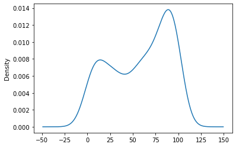

```python
df1.state_percentile_15.plot(kind="kde")
plt.show()
```

```python
sr
```

```
name                   0
school_rating          0
size                   0
reduced_lunch          0
state_percentile_16    0
state_percentile_15    0
stu_teach_ratio        0
school_type            0
avg_score_15           6
avg_score_16           0
full_time_teachers     0
percent_black          0
percent_white          0
percent_asian          0
percent_hispanic       0
dtype: int64
```

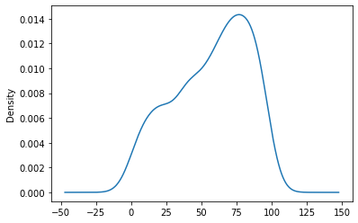

```python
df1.avg_score_15.plot(kind='kde')
plt.show()
```

```python
df1.avg_score_15 = df1.avg_score_15.fillna(df1.avg_score_15.median())
```

```python
df1.isnull().sum()
```

```
name                   0
school_rating          0
size                   0
reduced_lunch          0
state_percentile_16    0
state_percentile_15    0
stu_teach_ratio        0
school_type            0
avg_score_15           0
avg_score_16           0
full_time_teachers     0
percent_black          0
percent_white          0
percent_asian          0
percent_hispanic       0
dtype: int64
```

```python
def fill_missing_values(col):
    school_type=col[0]
    state_percentile_15=col[1]
    if pd.isnull(state_percentile_15):
        return df1[df1.school_type == school_type]['state_percentile_15'].mean()
    else:
        return state_percentile_15
```

```python
df1[["school_type","state_percentile_15"]].apply(fill_missing_values,axis=1)
```

```
0      95.8
1      37.3
2      83.6
3       1.0
4      89.2
       ...
342    65.2
343    97.0
344    76.7
345    97.1
346     1.2
Length: 347, dtype: float64
```

```python
df.isnull().sum()
```

```
name                   0
school_rating          0
size                   0
reduced_lunch          0
state_percentile_16    0
state_percentile_15    6
stu_teach_ratio        0
school_type            0
avg_score_15           6
avg_score_16           0
full_time_teachers     0
percent_black          0
percent_white          0
percent_asian          0
percent_hispanic       0
dtype: int64
```

```python
df[["school_type","state_percentile_15"]].apply(fill_missing_values,axis=1)
```

```
0      95.8
1      37.3
2      83.6
3       1.0
4      89.2
       ...
342    65.2
343    97.0
344    76.7
345    97.1
346     1.2
Length: 347, dtype: float64
```

```python
df.isnull().sum()
```

```
name                   0
school_rating          0
size                   0
reduced_lunch          0
state_percentile_16    0
state_percentile_15    6
stu_teach_ratio        0
school_type            0
avg_score_15           6
avg_score_16           0
full_time_teachers     0
percent_black          0
percent_white          0
percent_asian          0
percent_hispanic       0
dtype: int64
```

```python
df.state_percentile_15=df[["school_type","state_percentile_15"]].apply(fill_missing_values,axis=1)
```

```python
df.state_percentile_15.isnull().sum()
```

```
0
```

# Outliers

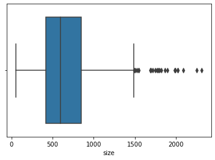

```python
import seaborn as sns
sns.boxplot(x=df1['size'])
```

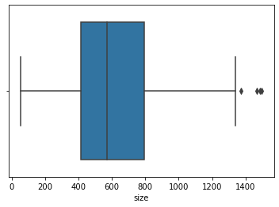

```python
df1_outlier_rem=df1[df1['size'].values < 1500]

sns.boxplot(x=df1_outlier_rem['size'])
```

```python
(df[df['size'] > 1500].shape[0]/df.shape[0])*100
```

```
6.051873198847262
```

```python
(df[df['size'] > 1500].shape[0]/df.shape[0])*100
```

```
6.051873198847262
```

```
array([[<AxesSubplot:title={'center':'size'}>]], dtype=object)
```

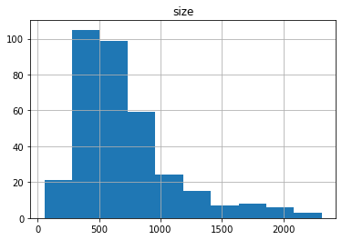

```python
df.hist('size')
```

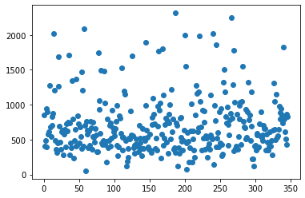

```python
import matplotlib.pyplot as plt
plt.scatter(df.index, df['size'])
```

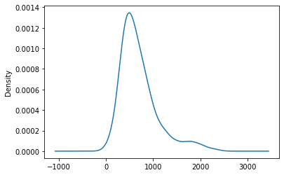

```python
df['size'].plot.kde()
```

## 1. StandardScaler

- The StandardScaler assumes your data is normally distributed within each feature and will scale them such that the distribution is now centred around 0, with a standard deviation of 1.
- Calculate - Subtract mean of column & div by standard deviation

[figure not shown]

- If data is not normally distributed, this is not the best scaler to use.

```python
#Generating normally distributed data
import numpy as np

df = pd.DataFrame({
    'x1': np.random.normal(0, 2, 10000),
    'x2': np.random.normal(5, 3, 10000),
    'x3': np.random.normal(-5, 5, 10000)
})
```

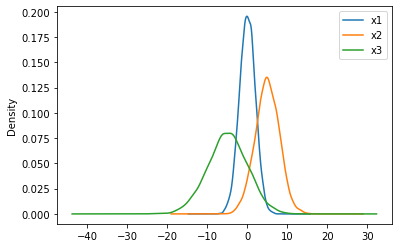

```python
# plotting data

df.plot.kde()
```

```python
from sklearn.preprocessing import StandardScaler

standardscaler = StandardScaler()
```

```python
data_tf = standardscaler.fit_transform(df)
```

```python
data_tf
```

```
array([[ 0.1813582 ,  0.16948646, -0.80992816],
       [-2.49832147, -0.80343189, -0.12172493],
       [ 0.18272951,  1.5631946 ,  0.26758614],
       ...,
       [ 0.44710075,  0.25046083, -1.21345511],
       [ 0.57905194,  0.64899024, -0.45711883],
       [-0.31853328, -0.87172008,  0.36863682]])
```

```python
df = pd.DataFrame(data_tf, columns=['x1','x2','x3'])
```

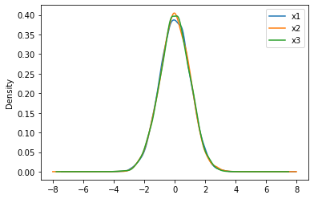

```python
df.plot.kde()
```

## 2. MinMaxScaler

- One of the most popular
- Calculate - Subtract min of column & div by difference between max & min

[figure not shown]

- Data shifts between 0 & 1
- If distribution not suitable for StandardScaler, this scaler works out.
- Sensitive to outliers

```python
import pandas as pd
import numpy as np
```

```python
df = pd.DataFrame({
    # positive skew
    'x1': np.random.chisquare(8, 1000),
    # negative skew
    'x2': np.random.beta(8, 2, 1000) * 40,
    # no skew
    'x3': np.random.normal(50, 3, 1000)
})
```

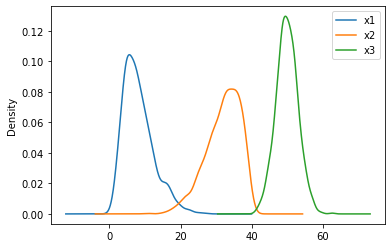

```python
df.plot.kde()
```

```python
from sklearn.preprocessing import MinMaxScaler
```

```python
minmax = MinMaxScaler()
data_tf = minmax.fit_transform(df)
```

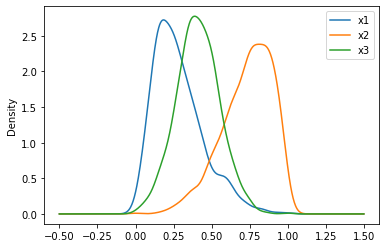

```python
df = pd.DataFrame(data_tf,columns=['x1','x2','x3'])
df.plot.kde()
```

```python
from sklearn.preprocessing import StandardScaler

standardscaler = StandardScaler()
```

```python
data_tf = standardscaler.fit_transform(df)
```

```python
df = pd.DataFrame(data_tf, columns=['x1','x2','x3'])
```

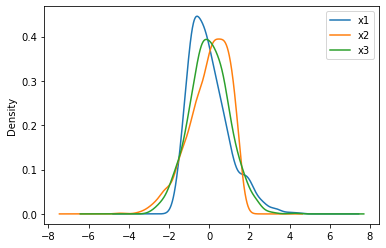

```python
df.plot.kde()
```

## 3. Robust Scaler

[figure not shown]

```python
df = pd.DataFrame({
    # Distribution with lower outliers
    'x1': np.concatenate([np.random.normal(20, 1, 1000), np.random.normal(1, 1, 25)]),
    # Distribution with higher outliers
    'x2': np.concatenate([np.random.normal(30, 1, 1000), np.random.normal(50, 1, 25)]),
})
```

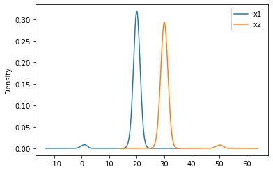

```python
df.plot.kde()
```

```python
from sklearn.preprocessing import RobustScaler
robustscaler = RobustScaler()
```

```python
data_tf = robustscaler.fit_transform(df)
df = pd.DataFrame(data_tf, columns=['x1','x2'])
```

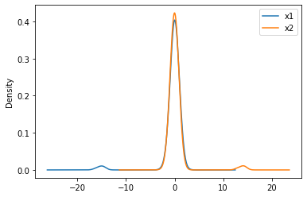

```python
df.plot.kde()
```

```python
df = pd.DataFrame({
    # Distribution with lower outliers
    'x1': np.concatenate([np.random.normal(20, 1, 1000), np.random.normal(1, 1, 25)]),
    # Distribution with higher outliers
    'x2': np.concatenate([np.random.normal(30, 1, 1000), np.random.normal(50, 1, 25)]),
})
```

```python
standardscaler = StandardScaler()
```

```python
data_tf = standardscaler.fit_transform(df)
```

```python
df = pd.DataFrame(data_tf, columns=['x1','x2'])
```

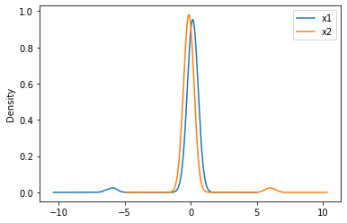

```python
df.plot.kde()
```

```python
df = pd.DataFrame({
    # Distribution with lower outliers
    'x1': np.concatenate([np.random.normal(20, 1, 1000), np.random.normal(1, 1, 25)]),
    # Distribution with higher outliers
    'x2': np.concatenate([np.random.normal(30, 1, 1000), np.random.normal(50, 1, 25)]),
})
```

```python
minmax = MinMaxScaler()
data_tf = minmax.fit_transform(df)
```

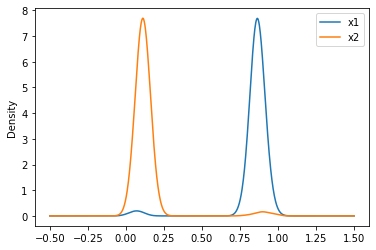

```python
df = pd.DataFrame(data_tf,columns=['x1','x2'])
df.plot.kde()
```

## Encoding Categorical Values

#### Encoding Ordinal Values

- Ordinal Values - Low, Medium & High. Relationship between values
- LabelEncoding with right mapping

```python
import pandas as pd
```

```python
df = pd.DataFrame({
    'Age':[33,44,22,44,55,22],
    'Income':['Low','Low','High','Medium','Medium','High']})
```

```python
df
```

|  | Age | Income |
| --- | --- | --- |
| 0 | 33 | Low |
| 1 | 44 | Low |
| 2 | 22 | High |
| 3 | 44 | Medium |
| 4 | 55 | Medium |
| 5 | 22 | High |

```python
df['income_encoded'] = df.Income.map({'Low':1,'Medium':2,'High':3})
```

```python
df
```

|  | Age | Income | income_encoded |
| --- | --- | --- | --- |
| 0 | 33 | Low | 1 |
| 1 | 44 | Low | 1 |
| 2 | 22 | High | 3 |
| 3 | 44 | Medium | 2 |
| 4 | 55 | Medium | 2 |
| 5 | 22 | High | 3 |

#### PS: We can use transformer class for this as well, we will see that later

#### Encoding Nominal Values

- Nominal Values - Male, Female. No relationship between data
- One Hot Encoding for converting data into one-hot vector

```python
df = pd.DataFrame({
    'Age':[33,44,22,44,55,22],
    'Gender':['Male','Female','Male','Female','Male','Male']})
```

```python
df.Gender.unique()
```

```
array(['Male', 'Female'], dtype=object)
```

```python
from sklearn.preprocessing import LabelEncoder,OneHotEncoder
```

```python
le = LabelEncoder()
df['gender_tf'] = le.fit_transform(df.Gender)
```

```python
df
```

|  | Age | Gender | gender_tf |
| --- | --- | --- | --- |
| 0 | 33 | Male | 1 |
| 1 | 44 | Female | 0 |
| 2 | 22 | Male | 1 |
| 3 | 44 | Female | 0 |
| 4 | 55 | Male | 1 |
| 5 | 22 | Male | 1 |

```python
ohe = OneHotEncoder()
res = ohe.fit_transform(df[['Gender']]).toarray()
```

```python
res
```

```
array([[0., 1.],
       [1., 0.],
       [0., 1.],
       [1., 0.],
       [0., 1.],
       [0., 1.]])
```

```python
df[['male', 'female']] = res
```

```python
df
```

|  | Age | Gender | gender_tf | male | female |
| --- | --- | --- | --- | --- | --- |
| 0 | 33 | Male | 1 | 0.0 | 1.0 |
| 1 | 44 | Female | 0 | 1.0 | 0.0 |
| 2 | 22 | Male | 1 | 0.0 | 1.0 |
| 3 | 44 | Female | 0 | 1.0 | 0.0 |
| 4 | 55 | Male | 1 | 0.0 | 1.0 |
| 5 | 22 | Male | 1 | 0.0 | 1.0 |

```python
df
```

|  | Age | Gender | gender_tf | male | female |
| --- | --- | --- | --- | --- | --- |
| 0 | 33 | Male | 1 | 0.0 | 1.0 |
| 1 | 44 | Female | 0 | 1.0 | 0.0 |
| 2 | 22 | Male | 1 | 0.0 | 1.0 |
| 3 | 44 | Female | 0 | 1.0 | 0.0 |
| 4 | 55 | Male | 1 | 0.0 | 1.0 |
| 5 | 22 | Male | 1 | 0.0 | 1.0 |

```python
pd.get_dummies(df, columns=['Gender'])
```

|  | Age | gender_tf | male | female | Gender_Female | Gender_Male |
| --- | --- | --- | --- | --- | --- | --- |
| 0 | 33 | 1 | 0.0 | 1.0 | 0 | 1 |
| 1 | 44 | 0 | 1.0 | 0.0 | 1 | 0 |
| 2 | 22 | 1 | 0.0 | 1.0 | 0 | 1 |
| 3 | 44 | 0 | 1.0 | 0.0 | 1 | 0 |
| 4 | 55 | 1 | 0.0 | 1.0 | 0 | 1 |
| 5 | 22 | 1 | 0.0 | 1.0 | 0 | 1 |

```python
df = pd.DataFrame({
    'Age':[33,44,22,44,55,22],
    'Income':['Low','Low','High','Medium','Medium','High']})
```

```python
df.Income.str.get_dummies()
```

|  | High | Low | Medium |
| --- | --- | --- | --- |
| 0 | 0 | 1 | 0 |
| 1 | 0 | 1 | 0 |
| 2 | 1 | 0 | 0 |
| 3 | 0 | 0 | 1 |
| 4 | 0 | 0 | 1 |
| 5 | 1 | 0 | 0 |

```python
pd.get_dummies(df['Income'])
```

|  | High | Low | Medium |
| --- | --- | --- | --- |
| 0 | 0 | 1 | 0 |
| 1 | 0 | 1 | 0 |
| 2 | 1 | 0 | 0 |
| 3 | 0 | 0 | 1 |
| 4 | 0 | 0 | 1 |
| 5 | 1 | 0 | 0 |

```python
from sklearn.datasets import fetch_openml # library for datasets

mnist = fetch_openml('mnist_784') # loading MNIST dataset
```

```python
mnist
```

[output not shown]

[output cut: 850 more lines]

[output not shown]

```python
mnist.keys()
```

```
dict_keys(['data', 'target', 'frame', 'categories', 'feature_names', 'target_names', 'DESCR', 'details', 'url'])
```

```python
print(mnist['DESCR'])
```

```
**Author**: Yann LeCun, Corinna Cortes, Christopher J.C. Burges
**Source**: [MNIST Website](http://yann.lecun.com/exdb/mnist/) - Date unknown
**Please cite**:

The MNIST database of handwritten digits with 784 features, raw data available at: http://yann.lecun.com/exdb/mnist/. It can be split in a training set of the first 60,000 examples, and a test set of 10,000 examples

It is a subset of a larger set available from NIST. The digits have been size-normalized and centered in a fixed-size image. It is a good database for people who want to try learning techniques and pattern recognition methods on real-world data while spending minimal efforts on preprocessing and for…

With some classification methods (particularly template-based methods, such as SVM and K-nearest neighbors), the error rate improves when the digits are centered by bounding box rather than center of mass. If you do this kind of pre-processing, you should report it in your publications. The MNIST da…

The MNIST training set is composed of 30,000 patterns from SD-3 and 30,000 patterns from SD-1. Our test set was composed of 5,000 patterns from SD-3 and 5,000 patterns from SD-1. The 60,000 pattern training set contained examples from approximately 250 writers. We made sure that the sets of writers …

Downloaded from openml.org.
```

```python
mnist['data'].shape
```

```
(70000, 784)
```

```python
mnist['target']
```

```
0        5
1        0
2        4
3        1
4        9
        ..
69995    2
69996    3
69997    4
69998    5
69999    6
Name: class, Length: 70000, dtype: category
Categories (10, object): ['0', '1', '2', '3', ..., '6', '7', '8', '9']
```

```python
x = mnist['data']
```

```python
x
```

|  | pixel1 | pixel2 | pixel3 | pixel4 | pixel5 | pixel6 | pixel7 | pixel8 | pixel9 | pixel10 | ... | pixel775 | pixel776 | pixel777 | pixel778 | pixel779 | pixel780 | pixel781 | pixel782 | pixel783 | pixel784 |
| --- | --- | --- | --- | --- | --- | --- | --- | --- | --- | --- | --- | --- | --- | --- | --- | --- | --- | --- | --- | --- | --- |
| 0 | 0.0 | 0.0 | 0.0 | 0.0 | 0.0 | 0.0 | 0.0 | 0.0 | 0.0 | 0.0 | ... | 0.0 | 0.0 | 0.0 | 0.0 | 0.0 | 0.0 | 0.0 | 0.0 | 0.0 | 0.0 |
| 1 | 0.0 | 0.0 | 0.0 | 0.0 | 0.0 | 0.0 | 0.0 | 0.0 | 0.0 | 0.0 | ... | 0.0 | 0.0 | 0.0 | 0.0 | 0.0 | 0.0 | 0.0 | 0.0 | 0.0 | 0.0 |
| 2 | 0.0 | 0.0 | 0.0 | 0.0 | 0.0 | 0.0 | 0.0 | 0.0 | 0.0 | 0.0 | ... | 0.0 | 0.0 | 0.0 | 0.0 | 0.0 | 0.0 | 0.0 | 0.0 | 0.0 | 0.0 |
| 3 | 0.0 | 0.0 | 0.0 | 0.0 | 0.0 | 0.0 | 0.0 | 0.0 | 0.0 | 0.0 | ... | 0.0 | 0.0 | 0.0 | 0.0 | 0.0 | 0.0 | 0.0 | 0.0 | 0.0 | 0.0 |
| 4 | 0.0 | 0.0 | 0.0 | 0.0 | 0.0 | 0.0 | 0.0 | 0.0 | 0.0 | 0.0 | ... | 0.0 | 0.0 | 0.0 | 0.0 | 0.0 | 0.0 | 0.0 | 0.0 | 0.0 | 0.0 |
| ... | ... | ... | ... | ... | ... | ... | ... | ... | ... | ... | ... | ... | ... | ... | ... | ... | ... | ... | ... | ... | ... |
| 69995 | 0.0 | 0.0 | 0.0 | 0.0 | 0.0 | 0.0 | 0.0 | 0.0 | 0.0 | 0.0 | ... | 0.0 | 0.0 | 0.0 | 0.0 | 0.0 | 0.0 | 0.0 | 0.0 | 0.0 | 0.0 |
| 69996 | 0.0 | 0.0 | 0.0 | 0.0 | 0.0 | 0.0 | 0.0 | 0.0 | 0.0 | 0.0 | ... | 0.0 | 0.0 | 0.0 | 0.0 | 0.0 | 0.0 | 0.0 | 0.0 | 0.0 | 0.0 |
| 69997 | 0.0 | 0.0 | 0.0 | 0.0 | 0.0 | 0.0 | 0.0 | 0.0 | 0.0 | 0.0 | ... | 0.0 | 0.0 | 0.0 | 0.0 | 0.0 | 0.0 | 0.0 | 0.0 | 0.0 | 0.0 |
| 69998 | 0.0 | 0.0 | 0.0 | 0.0 | 0.0 | 0.0 | 0.0 | 0.0 | 0.0 | 0.0 | ... | 0.0 | 0.0 | 0.0 | 0.0 | 0.0 | 0.0 | 0.0 | 0.0 | 0.0 | 0.0 |
| 69999 | 0.0 | 0.0 | 0.0 | 0.0 | 0.0 | 0.0 | 0.0 | 0.0 | 0.0 | 0.0 | ... | 0.0 | 0.0 | 0.0 | 0.0 | 0.0 | 0.0 | 0.0 | 0.0 | 0.0 | 0.0 |

70000 rows × 784 columns

```python
x.shape
```

```
(70000, 784)
```

```python
x
```

|  | pixel1 | pixel2 | pixel3 | pixel4 | pixel5 | pixel6 | pixel7 | pixel8 | pixel9 | pixel10 | ... | pixel775 | pixel776 | pixel777 | pixel778 | pixel779 | pixel780 | pixel781 | pixel782 | pixel783 | pixel784 |
| --- | --- | --- | --- | --- | --- | --- | --- | --- | --- | --- | --- | --- | --- | --- | --- | --- | --- | --- | --- | --- | --- |
| 0 | 0.0 | 0.0 | 0.0 | 0.0 | 0.0 | 0.0 | 0.0 | 0.0 | 0.0 | 0.0 | ... | 0.0 | 0.0 | 0.0 | 0.0 | 0.0 | 0.0 | 0.0 | 0.0 | 0.0 | 0.0 |
| 1 | 0.0 | 0.0 | 0.0 | 0.0 | 0.0 | 0.0 | 0.0 | 0.0 | 0.0 | 0.0 | ... | 0.0 | 0.0 | 0.0 | 0.0 | 0.0 | 0.0 | 0.0 | 0.0 | 0.0 | 0.0 |
| 2 | 0.0 | 0.0 | 0.0 | 0.0 | 0.0 | 0.0 | 0.0 | 0.0 | 0.0 | 0.0 | ... | 0.0 | 0.0 | 0.0 | 0.0 | 0.0 | 0.0 | 0.0 | 0.0 | 0.0 | 0.0 |
| 3 | 0.0 | 0.0 | 0.0 | 0.0 | 0.0 | 0.0 | 0.0 | 0.0 | 0.0 | 0.0 | ... | 0.0 | 0.0 | 0.0 | 0.0 | 0.0 | 0.0 | 0.0 | 0.0 | 0.0 | 0.0 |
| 4 | 0.0 | 0.0 | 0.0 | 0.0 | 0.0 | 0.0 | 0.0 | 0.0 | 0.0 | 0.0 | ... | 0.0 | 0.0 | 0.0 | 0.0 | 0.0 | 0.0 | 0.0 | 0.0 | 0.0 | 0.0 |
| ... | ... | ... | ... | ... | ... | ... | ... | ... | ... | ... | ... | ... | ... | ... | ... | ... | ... | ... | ... | ... | ... |
| 69995 | 0.0 | 0.0 | 0.0 | 0.0 | 0.0 | 0.0 | 0.0 | 0.0 | 0.0 | 0.0 | ... | 0.0 | 0.0 | 0.0 | 0.0 | 0.0 | 0.0 | 0.0 | 0.0 | 0.0 | 0.0 |
| 69996 | 0.0 | 0.0 | 0.0 | 0.0 | 0.0 | 0.0 | 0.0 | 0.0 | 0.0 | 0.0 | ... | 0.0 | 0.0 | 0.0 | 0.0 | 0.0 | 0.0 | 0.0 | 0.0 | 0.0 | 0.0 |
| 69997 | 0.0 | 0.0 | 0.0 | 0.0 | 0.0 | 0.0 | 0.0 | 0.0 | 0.0 | 0.0 | ... | 0.0 | 0.0 | 0.0 | 0.0 | 0.0 | 0.0 | 0.0 | 0.0 | 0.0 | 0.0 |
| 69998 | 0.0 | 0.0 | 0.0 | 0.0 | 0.0 | 0.0 | 0.0 | 0.0 | 0.0 | 0.0 | ... | 0.0 | 0.0 | 0.0 | 0.0 | 0.0 | 0.0 | 0.0 | 0.0 | 0.0 | 0.0 |
| 69999 | 0.0 | 0.0 | 0.0 | 0.0 | 0.0 | 0.0 | 0.0 | 0.0 | 0.0 | 0.0 | ... | 0.0 | 0.0 | 0.0 | 0.0 | 0.0 | 0.0 | 0.0 | 0.0 | 0.0 | 0.0 |

70000 rows × 784 columns

```python
from matplotlib import pyplot as plt
```

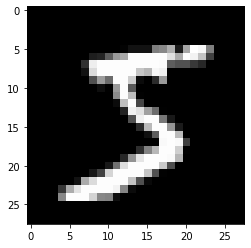

```python
plt.imshow(x.values[0].reshape(28,28), cmap='gray')
```

```python
plt.imshow(x[0].reshape(28,28), cmap='gray')
```

[output not shown]

```python
mnist['target'][0]
```

```
'5'
```

```python
from sklearn.preprocessing import StandardScaler
```

```python
sc = StandardScaler()
```

```python
x_std = sc.fit_transform(x)
```

```python
x_std.shape
```

```
(70000, 784)
```

```python
x_std
```

```
array([[0., 0., 0., ..., 0., 0., 0.],
       [0., 0., 0., ..., 0., 0., 0.],
       [0., 0., 0., ..., 0., 0., 0.],
       ...,
       [0., 0., 0., ..., 0., 0., 0.],
       [0., 0., 0., ..., 0., 0., 0.],
       [0., 0., 0., ..., 0., 0., 0.]])
```

```python
from sklearn.decomposition import PCA
```

```python
pca = PCA()
```

```python
pca.fit(x_std)
```

```
PCA()
```

```python
pca.explained_variance_ratio_
```

```
array([5.64271890e-02, 4.04122588e-02, 3.73827333e-02, 2.89299967e-02,
       2.52075176e-02, 2.19254904e-02, 1.91428200e-02, 1.74068380e-02,
       1.53223192e-02, 1.39608655e-02, 1.34217502e-02, 1.20142136e-02,
       1.11396188e-02, 1.09058166e-02, 1.02798565e-02, 9.94954818e-03,
       9.31255447e-03, 9.19634749e-03, 8.88599812e-03, 8.63195357e-03,
       8.21741429e-03, 7.98416580e-03, 7.62572887e-03, 7.42315294e-03,
       7.16569784e-03, 6.89313988e-03, 6.81399054e-03, 6.54587652e-03,
       6.27293368e-03, 6.10345345e-03, 5.97260805e-03, 5.89303875e-03,
       5.67358491e-03, 5.59357597e-03, 5.52473105e-03, 5.34443453e-03,
       5.27593434e-03, 5.15841172e-03, 5.05498061e-03, 4.77437784e-03,
       4.76312011e-03, 4.65154837e-03, 4.53454310e-03, 4.45757102e-03,
       4.42312508e-03, 4.37877290e-03, 4.37293648e-03, 4.27723692e-03,
       4.24807888e-03, 4.18523984e-03, 4.04059497e-03, 3.96258302e-03,
       3.93175520e-03, 3.90561562e-03, 3.86443636e-03, 3.77500874e-03,
       3.73882776e-03, 3.68328451e-03, 3.60376886e-03, 3.56369533e-03,
       3.49288565e-03, 3.44527400e-03, 3.43238797e-03, 3.40999789e-03,
       3.34463427e-03, 3.32107278e-03, 3.29803237e-03, 3.19433128e-03,
       3.17109847e-03, 3.15431216e-03, 3.09940692e-03, 3.05782213e-03,
       3.05095386e-03, 3.03960430e-03, 2.96634548e-03, 2.92957769e-03,
       2.91295177e-03, 2.90232456e-03, 2.88608315e-03, 2.87021809e-03,
       2.84514495e-03, 2.81523948e-03, 2.79244643e-03, 2.78629327e-03,
       2.78232823e-03, 2.76732768e-03, 2.75419880e-03, 2.72901182e-03,
       2.68739705e-03, 2.68138665e-03, 2.67354465e-03, 2.63003129e-03,
       2.62154625e-03, 2.58872121e-03, 2.58428890e-03, 2.57099877e-03,
       2.51899615e-03, 2.50903962e-03, 2.48093637e-03, 2.44092479e-03,
       2.43607388e-03, 2.41671291e-03, 2.38998862e-03, 2.36394489e-03,
       2.35632294e-03, 2.32325931e-03, 2.29150647e-03, 2.25292392e-03,
       2.23890823e-03, 2.23220136e-03, 2.19713535e-03, 2.19025774e-03,
       2.15302794e-03, 2.13446727e-03, 2.10763114e-03, 2.10123385e-03,
       2.06525182e-03, 2.05073001e-03, 2.02905625e-03, 1.98907275e-03,
       1.97597384e-03, 1.96587825e-03, 1.95393761e-03, 1.94545299e-03,
       1.92833719e-03, 1.91505128e-03, 1.89259781e-03, 1.88400400e-03,
       1.86304259e-03, 1.81890014e-03, 1.80675538e-03, 1.79008574e-03,
       1.78407071e-03, 1.76998521e-03, 1.75852488e-03, 1.74780272e-03,
       1.73303762e-03, 1.72800463e-03, 1.69432572e-03, 1.67647665e-03,
       1.65855042e-03, 1.64975449e-03, 1.64602540e-03, 1.64149385e-03,
       1.61138401e-03, 1.60413215e-03, 1.58926668e-03, 1.56600855e-03,
       1.56230527e-03, 1.54815007e-03, 1.53566116e-03, 1.52616879e-03,
       1.51562131e-03, 1.49189363e-03, 1.48880393e-03, 1.47098209e-03,
       1.46273885e-03, 1.44915762e-03, 1.44201670e-03, 1.42794935e-03,
```

[output cut: 141 more lines]

```
       2.36377098e-34, 2.36377098e-34, 2.36377098e-34, 2.36377098e-34,
       2.36377098e-34, 2.36377098e-34, 2.36377098e-34, 2.36377098e-34,
       2.36377098e-34, 2.36377098e-34, 2.36377098e-34, 2.36377098e-34,
       2.36377098e-34, 2.36377098e-34, 2.36377098e-34, 2.36377098e-34,
       2.36377098e-34, 2.36377098e-34, 2.36377098e-34, 2.36377098e-34,
       2.36377098e-34, 2.36377098e-34, 2.36377098e-34, 2.36377098e-34,
       2.36377098e-34, 2.36377098e-34, 2.36377098e-34, 2.36377098e-34,
       2.36377098e-34, 2.36377098e-34, 2.36377098e-34, 2.36377098e-34,
       2.36377098e-34, 2.36377098e-34, 2.36377098e-34, 2.36377098e-34,
       2.36377098e-34, 2.36377098e-34, 2.36377098e-34, 2.36377098e-34,
       2.36377098e-34, 2.36377098e-34, 2.36377098e-34, 2.36377098e-34,
       2.36377098e-34, 2.36377098e-34, 2.36377098e-34, 2.36377098e-34,
       2.36377098e-34, 2.36377098e-34, 2.36377098e-34, 2.36377098e-34,
       2.36377098e-34, 2.36377098e-34, 2.36377098e-34, 2.36377098e-34,
       1.59916566e-34, 1.30471465e-34, 8.72541123e-35, 1.70895914e-35])
```

```python
import matplotlib.pyplot as plt
import numpy as np
```

```
<BarContainer object of 784 artists>
```

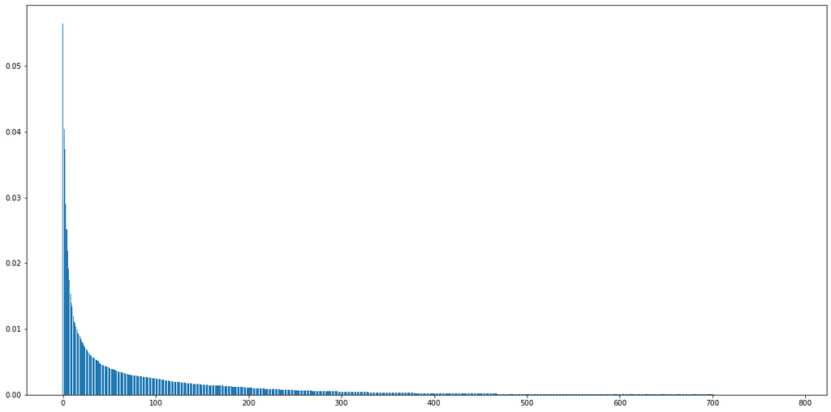

```python
plt.figure(figsize=(20,10))
plt.bar(np.arange(len(pca.explained_variance_ratio_)), pca.explained_variance_ratio_)
```

```
<BarContainer object of 784 artists>
```

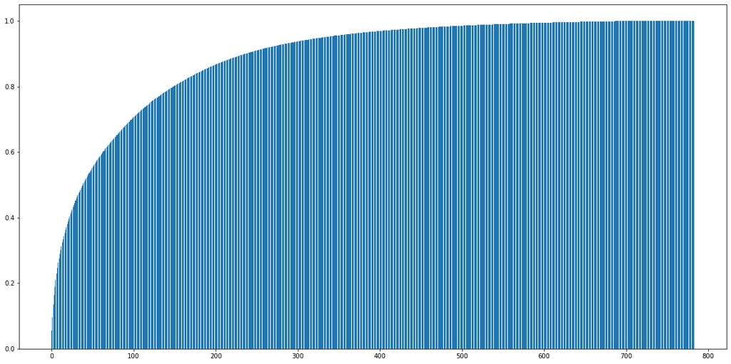

```python
plt.figure(figsize=(20,10))
plt.bar(np.arange(len(pca.explained_variance_ratio_)), pca.explained_variance_ratio_.cumsum())
```

```python
var_per = pca.explained_variance_ratio_.cumsum()
```

```python
var_per[var_per < 0.95]
```

```
array([0.05642719, 0.09683945, 0.13422218, 0.16315218, 0.1883597 ,
       0.21028519, 0.22942801, 0.24683484, 0.26215716, 0.27611803,
       0.28953978, 0.30155399, 0.31269361, 0.32359943, 0.33387928,
       0.34382883, 0.35314139, 0.36233773, 0.37122373, 0.37985569,
       0.3880731 , 0.39605727, 0.403683  , 0.41110615, 0.41827185,
       0.42516499, 0.43197898, 0.43852485, 0.44479779, 0.45090124,
       0.45687385, 0.46276689, 0.46844047, 0.47403405, 0.47955878,
       0.48490321, 0.49017915, 0.49533756, 0.50039254, 0.50516692,
       0.50993004, 0.51458159, 0.51911613, 0.5235737 , 0.52799683,
       0.5323756 , 0.53674853, 0.54102577, 0.54527385, 0.54945909,
       0.55349969, 0.55746227, 0.56139402, 0.56529964, 0.56916408,
       0.57293908, 0.57667791, 0.5803612 , 0.58396497, 0.58752866,
       0.59102155, 0.59446682, 0.59789921, 0.60130921, 0.60465384,
       0.60797491, 0.61127295, 0.61446728, 0.61763838, 0.62079269,
       0.62389209, 0.62694992, 0.63000087, 0.63304047, 0.63600682,
       0.6389364 , 0.64184935, 0.64475167, 0.64763776, 0.65050798,
       0.65335312, 0.65616836, 0.65896081, 0.6617471 , 0.66452943,
       0.66729676, 0.67005095, 0.67277997, 0.67546736, 0.67814875,
       0.68082229, 0.68345233, 0.68607387, 0.68866259, 0.69124688,
       0.69381788, 0.69633688, 0.69884592, 0.70132685, 0.70376778,
       0.70620385, 0.70862056, 0.71101055, 0.7133745 , 0.71573082,
       0.71805408, 0.72034559, 0.72259851, 0.72483742, 0.72706962,
       0.72926676, 0.73145701, 0.73361004, 0.73574451, 0.73785214,
       0.73995337, 0.74201863, 0.74406936, 0.74609841, 0.74808748,
       0.75006346, 0.75202934, 0.75398327, 0.75592873, 0.75785706,
       0.75977212, 0.76166471, 0.76354872, 0.76541176, 0.76723066,
       0.76903742, 0.7708275 , 0.77261157, 0.77438156, 0.77614008,
       0.77788788, 0.77962092, 0.78134893, 0.78304325, 0.78471973,
       0.78637828, 0.78802803, 0.78967406, 0.79131555, 0.79292694,
       0.79453107, 0.79612034, 0.79768635, 0.79924865, 0.8007968 ,
       0.80233246, 0.80385863, 0.80537425, 0.80686615, 0.80835495,
       0.80982593, 0.81128867, 0.81273783, 0.81417984, 0.81560779,
       0.81703024, 0.81845068, 0.81985084, 0.8212439 , 0.82263539,
       0.82402588, 0.82541484, 0.826801  , 0.82818551, 0.82955   ,
       0.83090787, 0.83225938, 0.83360837, 0.83494634, 0.83627269,
       0.83758618, 0.83888475, 0.8401775 , 0.84146453, 0.8427354 ,
       0.84399924, 0.84525765, 0.84649268, 0.84771415, 0.84893098,
       0.85014232, 0.85134219, 0.8525381 , 0.85371509, 0.85488725,
       0.85605211, 0.85720405, 0.85835274, 0.85949533, 0.86062872,
       0.86175234, 0.86286214, 0.86394784, 0.86502912, 0.86609176,
```

[output cut: 12 more lines]

```
       0.91634572, 0.91697204, 0.91759067, 0.91820724, 0.9188158 ,
       0.91942015, 0.92001858, 0.92060582, 0.92118667, 0.92176267,
       0.92233582, 0.92290653, 0.92347112, 0.92403138, 0.92458852,
       0.92513804, 0.92568514, 0.92622918, 0.92677076, 0.92730925,
       0.92784524, 0.92837175, 0.92889663, 0.92941462, 0.92992961,
       0.93044213, 0.93094791, 0.93145029, 0.93194893, 0.93244517,
       0.93293957, 0.9334307 , 0.93391247, 0.93439094, 0.93486745,
       0.93534296, 0.93581443, 0.93627534, 0.93673359, 0.93718337,
       0.93763178, 0.93807969, 0.93852267, 0.93896147, 0.93939873,
       0.93983134, 0.94026169, 0.94068449, 0.94110406, 0.94152088,
       0.94193631, 0.94234866, 0.94275958, 0.94316852, 0.94357608,
       0.94397833, 0.9443781 , 0.94477481, 0.94516646, 0.94555564,
       0.94594321, 0.94632981, 0.94671256, 0.9470913 , 0.94746948,
       0.94784415, 0.94821593, 0.94858589, 0.94895259, 0.94931357,
       0.94967269])
```

```python
var_per[var_per < 0.95].shape
```

```
(331,)
```

```python
pca = PCA(n_components = 331)
```

```python
x_trf = pca.fit_transform(x_std)
```

```python
x_trf.shape
```

```
(70000, 331)
```

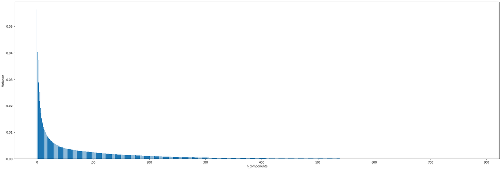

```python
from sklearn.preprocessing import StandardScaler
from sklearn.decomposition import PCA as sklearnPCA
import matplotlib.pyplot as plt
import numpy as np

#standardized data
sc = StandardScaler()
sc.fit(x)
X_std = sc.transform(x)

#If n_components is not set then all components are stored
pca = sklearnPCA()
sklearn_pca = pca.fit(X_std)

var_per = sklearn_pca.explained_variance_ratio_
cum_var_per = sklearn_pca.explained_variance_ratio_.cumsum()

plt.figure(figsize=(30,10))
ind = np.arange(len(var_per))
plt.bar(ind,var_per)
plt.xlabel('n_components')
plt.ylabel('Variance')
```

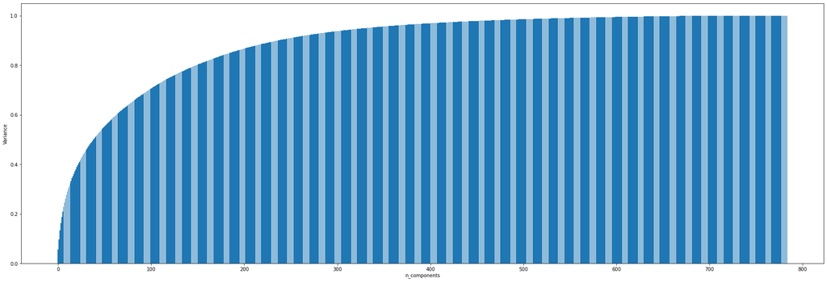

```python
plt.figure(figsize=(30,10))
ind = np.arange(len(cum_var_per))
plt.bar(ind,cum_var_per)
plt.xlabel('n_components')
plt.ylabel('Variance')
```

```python
len(cum_var_per[cum_var_per < 0.95])
```

```
331
```

```python
pca = sklearnPCA(n_components = len(cum_var_per[cum_var_per < 0.95]))
X_trans = pca.fit_transform(X_std)
```

```python
X_trans.shape
```

```
(70000, 331)
```

```python
from sklearn.datasets import fetch_openml # library for datasets

mnist = fetch_openml('mnist_784') # loading MNIST dataset
```

```python
mnist.keys()
```

```
dict_keys(['data', 'target', 'frame', 'categories', 'feature_names', 'target_names', 'DESCR', 'details', 'url'])
```

```python
x = mnist['data']
```

```python
y = mnist['target']
```

```python
from sklearn.preprocessing import StandardScaler
```

```python
sc = StandardScaler()
```

```python
x_std = sc.fit_transform(x)
```

```python
x_std.shape
```

```
(70000, 784)
```

```python
from sklearn.discriminant_analysis import LinearDiscriminantAnalysis
lda = LinearDiscriminantAnalysis()
sklearn_lda = lda.fit(x_std, y)

var_per = sklearn_lda.explained_variance_ratio_
cum_var_per = sklearn_lda.explained_variance_ratio_.cumsum()
```

```python
cum_var_per
```

```
array([0.23718291, 0.44064934, 0.617996  , 0.72502353, 0.81942663,
       0.88849806, 0.93862739, 0.97309696, 1.        ])
```

```python
len(cum_var_per[cum_var_per < 0.95])
```

```
7
```

```python
sklearn_lda.fit_transform(x_std, y)
```

```
array([[-0.9815313 , -0.60674231, -1.65255425, ...,  0.73096093,
         1.78688392, -0.96866992],
       [-3.05892432, -3.05284985, -2.88173559, ...,  0.43035835,
        -0.90883765, -0.17645317],
       [ 1.85791007, -0.05752316,  1.11624349, ...,  2.04871221,
         1.71002227,  2.87380323],
       ...,
       [ 3.12523695, -0.84419027,  2.06665897, ..., -0.06651955,
         0.28546004,  0.44446854],
       [-0.92950977,  0.79599839, -1.4049491 , ..., -2.09722096,
         2.56354996,  0.02696681],
       [-3.78310457, -1.7814597 ,  6.61480248, ...,  0.67214626,
        -0.67069241,  0.38933558]])
```